# Exercise III

Linear model

```r
knitr::opts_chunk$set(
    fig.width = 6,
    fig.asp   = 1,
    fig.align = "center",
    message   = FALSE,
    warning   = FALSE
)
```

```r
library(tidyverse)
library(broom)      # for extracting tidy data frames from statistical objects
library(car)        # general functions related to linear models, in particular Anova function
library(heplots)    # for eta-square calculations, i.e. etasq function
library(emmeans)    # for pairwise contrasts
library(gt)         # for making nice tables
library(effsize)    # for Cohen's d and Glass' delta
library(sandwich)   # For heteroscedasticity-consistent variance-covariance estimators
library(lmtest)     # For regression coefficients tests with custom variance-covariance matrices, i.e. coeftest function
library(simpleboot) # For easy bootstraping of regression models
library(lme4)
library(lmerTest)
library(rcompanion)
library(interactions)
library(ggplot2)
library(ggpubr)
library(e1071)
library(DescTools)
library(MuMIn)
## GGplot settings
theme_set(theme_bw())
```

# Pen-and-paper problems

## 1. (2 points)

Let:

$$\mathbf{X} =
\begin{pmatrix}
1 & 3 \\
2 & 2 \\
4 & 3 \\
2 & 0
\end{pmatrix}$$

- Calculate $\mathbf{X}^\top\mathbf{X}$ and calculate its determinant (you can do this with a simple function in `R`, examples are in one of the notebooks and in HW2 solutions).

Answer:

$$\mathbf{X}^\top =
\begin{pmatrix}
1 & 2 & 4 & 2\\
3 & 2 & 3 & 0
\end{pmatrix}
\\\mathbf{X}^\top\mathbf{X} =
\begin{pmatrix}
1 & 2 & 4 & 2\\
3 & 2 & 3 & 0
\end{pmatrix}
\begin{pmatrix}
1 & 3 \\
2 & 2 \\
4 & 3 \\
2 & 0
\end{pmatrix} =
\\\begin{pmatrix}
1*1 + 2*2 + 4*4 + 2*2 & 1*3 + 2*2 + 4*3 + 2*0 \\
3*1 + 2*2 + 3*4 + 0*2 & 3*3 + 2*2 + 3*3 + 0*0
\end{pmatrix} =
\\\mathbf{X}^\top\mathbf{X} =
\begin{pmatrix}
25 & 19 \\
19 & 22
\end{pmatrix}$$

```r
X <- matrix(c(
    25, 19,
    19, 22
), byrow = TRUE, ncol = 2L)

det(X)
```

```
[1] 189
```

Determinant of this matrix is 189.

- What are dimensions of $\mathbf{X}^\top\mathbf{X}$?

$X\in\mathbb{R}^{2x2}$

- Is $\mathbf{X}^\top\mathbf{X}$ of full rank?

Matrix $\mathbf{X}^\top\mathbf{X}$ is square and its determinant is not 0, so it is of full rank

- What does it tell you about column rank of $\mathbf{X}$?

X is a matrix over the real numbers, so $\text{rank}(\mathbf{X}^\top\mathbf{X}) = \text{rank}(\mathbf{X})$

$\mathbf{X}^\top\mathbf{X}$ is of full rank, so $\mathbf{X}$ is also of full rank. Therefore, if $\mathbf{X}$ is of full rank, it is also of full column rank.

- To what kinds of matrices important in statistics is $\mathbf{X}^\top\mathbf{X}$ related?

$\mathbf{X}^\top\mathbf{X}$ is a matrix of sum-of-squares-and-cross-products and it is related to the regression analysis topic, specifically to variance-covariance matrix of the predictor variables.

## 2. (2 points)

Let $A_1, A_2, \ldots, A_n$ be $n$ independent events. Derive the most concise formula you can for the probability of an event that at least one of these events happens.

ANSWER:

Probability that none of the events $A_1, \ldots A_n$ happens:

$Pr(A_1^c \cap A_2^c \cap \ldots \cap A_n^c)$

Probability of an event that at least one of these events happens

$$Pr(A_1^c \cap A_2^c \cap \ldots \cap A_n^c)^c = Pr(A_1 \cup A_2 \cup \ldots \cup A_n)$$

## 3. (2 points)

Consider the following (non-linear) regression equation:

$$\hat{y}_i = B_0e^{b_1x_i}$$

- In what scale (under what transformation) is the above equation linear. Write down this equation.

Log transformation using natural logarithm

$$\hat{y}_i = B_0e^{b_1x_i}
\\ln(\hat{y}_i) = ln(B_0e^{b_1x_i})
\\ln(\hat{y}_i) = ln(B_0) + ln(e^{b_1x_i})
\\ln(\hat{y}_i) = ln(B_0) + b_1x_i$$

- Write down the formula for $y_i$ in the linear scale (add the error term $u_i$) and convert back to the original scale.

Applying $e$ to both sides of the equation

$$ln(\hat{y}_i) = ln(B_0) + b_1x_i + u_i
\\e^{ln(\hat{y}_i)} = e^{ln(B_0) + b_1x_i + u_i}
\\e^{ln(\hat{y}_i)} = e^{ln(B_0)} * e^{b_1x_i+u_i}
\\\hat{y}_i = B_0 e^{b_1x_i+u_i}
\\\hat{y}_i = B_0 e^{b_1x_i} e^{u_i}$$

- Is there any important qualitative difference between how the error term affect the result in the linear scale and original scale?

In original scale, error term affects the result more, as increasing $u_i$ by 1 multiplies $y$ by $e$. In the linear scale increasing $u_i$ by 1 increases $y$ by $1$. It means that in linear scale the model is linear and additive and in original scale it is multiplicative.

- How does $\hat{y}_i$ change when $x_i$ increases by $1$.

For linear regression:

Under the assumption that all other values remain the same, increasing $x_i$ by $1$ increases $\hat{y}_i$ by $b_1$.

For exponential regression:

Under the assumption that all other values remain the same, increasing $x_i$ by $1$ value of $\hat{y}_i$ is multiplied by $e^{b_1}$.

## 4. (2 points)

In this exercise we will derive a coding scheme known as Helmert coding (or reversed Helmert coding, opinions tend to differ). For simplicity we will do this only for three groups. This coding scheme should yield regression coefficients with the following interpretations:

- $b_0$ should be equal to the arithmetic average of group means.
- $b_1$ should be equal to the difference between the second and the first group.
- $b_2$ should be equal to the difference between the third group and the average of the means in the first two groups.
- Test your result using the following code.

$$\textbf {W} = \begin{pmatrix}
\frac {1}{3} & -1 & -\frac {1}{2} \\
\frac {1}{3} & 1 & -\frac {1}{2} \\
\frac {1}{3} & 0 & 1
\end{pmatrix}$$

```r
# DEFINE THE HYPOTHESIS MATRIX HERE
W <- matrix(c(
    1/3, -1, -1/2,
    1/3, 1, -1/2,
    1/3, 0, 1
), ncol = 3)

# CONTRAST MATRIX (INVERSE OF W)
C <- matrix(c(
    1, 1, 1,
    -1/2, 1/2, 0,
    -1/3, -1/3, 2/3
), ncol = 3)


model <- lm(Sepal.Length ~ Species, data = iris, contrasts = list(Species = C[, -1]))
coef(model)
```

```
(Intercept)    Species1    Species2
   5.843333    0.930000    1.117000
```

```r
# COMPARE TO OBSERVED GROUP MEANS
M <- tapply(iris$Sepal.Length, iris$Species, mean)
```

## 5. (2 points)

Let $X_1, X_2, X_3, X_4, X_5, X_6$ be six measurements (realizations of six random variables).

- Write down variance-covariance matrix for the vector of the six measurements assuming they correspond to different subjects.

$$\text{Var}[\mathbf{x}] =
\begin{pmatrix}
\text{Var}[\mathbf{X_1}] & \text{Cov}[\mathbf{X_1, X_2}] & \text{Cov}[\mathbf{X_1, X_3}] & \text{Cov}[\mathbf{X_1, X_4}] & \text{Cov}[\mathbf{X_1, X_5}] & \text{Cov}[\mathbf{X_1, X_6}]\\
\text{Cov}[\mathbf{X_2, X_1}] & \text{Var}[\mathbf{X_2}] & \text{Cov}[\mathbf{X_2, X_3}] & \text{Cov}[\mathbf{X_2, X_4}] & \text{Cov}[\mathbf{X_2, X_5}] & \text{Cov}[\mathbf{X_2, X_6}]\\
\text{Cov}[\mathbf{X_3, X_1}] & \text{Cov}[\mathbf{X_3, X_2}] & \text{Var}[\mathbf{X_3}] & \text{Cov}[\mathbf{X_3, X_4}] & \text{Cov}[\mathbf{X_3, X_5}] & \text{Cov}[\mathbf{X_3, X_6}]\\
\text{Cov}[\mathbf{X_4, X_1}] & \text{Cov}[\mathbf{X_4, X_2}] & \text{Cov}[\mathbf{X_4, X_3}] & \text{Var}[\mathbf{X_4}] & \text{Cov}[\mathbf{X_4, X_5}] & \text{Cov}[\mathbf{X_4, X_6}]\\
\text{Cov}[\mathbf{X_5, X_1}] & \text{Cov}[\mathbf{X_5, X_2}] & \text{Cov}[\mathbf{X_5, X_3}] & \text{Cov}[\mathbf{X_5, X_4}] & \text{Var}[\mathbf{X_5}] & \text{Cov}[\mathbf{X_5, X_6}]\\
\text{Cov}[\mathbf{X_6, X_1}] & \text{Cov}[\mathbf{X_6, X_2}] & \text{Cov}[\mathbf{X_6, X_3}] & \text{Cov}[\mathbf{X_6, X_4}] & \text{Cov}[\mathbf{X_6, X_5}] & \text{Var}[\mathbf{X_6}]
\end{pmatrix}$$

You may assume that they may have different variances. * Write down variance-covariance matrix for the vector of the six measurements assuming that the first three belong to one subject and the last three to another subject. Assume that variances/covariances within the subject are the same and that measurements for different subjects are independent.

$$\text{Var}[\mathbf{x}] =
\begin{pmatrix}
\text{Var}[\mathbf{X_1}] & \text{Var}[\mathbf{X_1}] & \text{Var}[\mathbf{X_1}] & 0 & 0 & 0\\
\text{Var}[\mathbf{X_2}] & \text{Var}[\mathbf{X_2}] & \text{Var}[\mathbf{X_2}] & 0 & 0 & 0\\
\text{Var}[\mathbf{X_3}] & \text{Var}[\mathbf{X_3}] & \text{Var}[\mathbf{X_3}] & 0 & 0 & 0\\
0 & 0 & 0 & \text{Var}[\mathbf{X_4}] & \text{Var}[\mathbf{X_4}] & \text{Var}[\mathbf{X_4}]\\
0 & 0 & 0 & \text{Var}[\mathbf{X_5}] & \text{Var}[\mathbf{X_5}] & \text{Var}[\mathbf{X_5}]\\
0 & 0 & 0 & \text{Var}[\mathbf{X_6}] & \text{Var}[\mathbf{X_6}] & \text{Var}[\mathbf{X_6}]
\end{pmatrix}$$

- What kind of model you may use to deal with this kind of correlation structure?

Model with random effects for experiments with repeated measurements

# Coding problems

## 1. (2 points)

Use `Cowles` dataset from `carData` package. It is a very simple dataset on psychological correlates of volunteering (see `?Cowles` for details). Build an appropriate statistical model for explaining `volunteer` variable. Report your results properly and try to visualize your results in a legible manner.

```r
data(Cowles)
(Cowles <- tibble(Cowles))
```

```
# A tibble: 1,421 x 4
   neuroticism extraversion sex    volunteer
         <int>        <int> <fct>  <fct>
 1          16           13 female no
 2           8           14 male   no
 3           5           16 male   no
 4           8           20 female no
 5           9           19 male   no
 6           6           15 male   no
 7           8           10 female no
 8          12           11 male   no
 9          15           16 male   no
10          18            7 male   no
# ... with 1,411 more rows
```

```r
Cowles <- Cowles %>% mutate(
    volunteerYes = ifelse(volunteer == "yes", 1, 0))
```

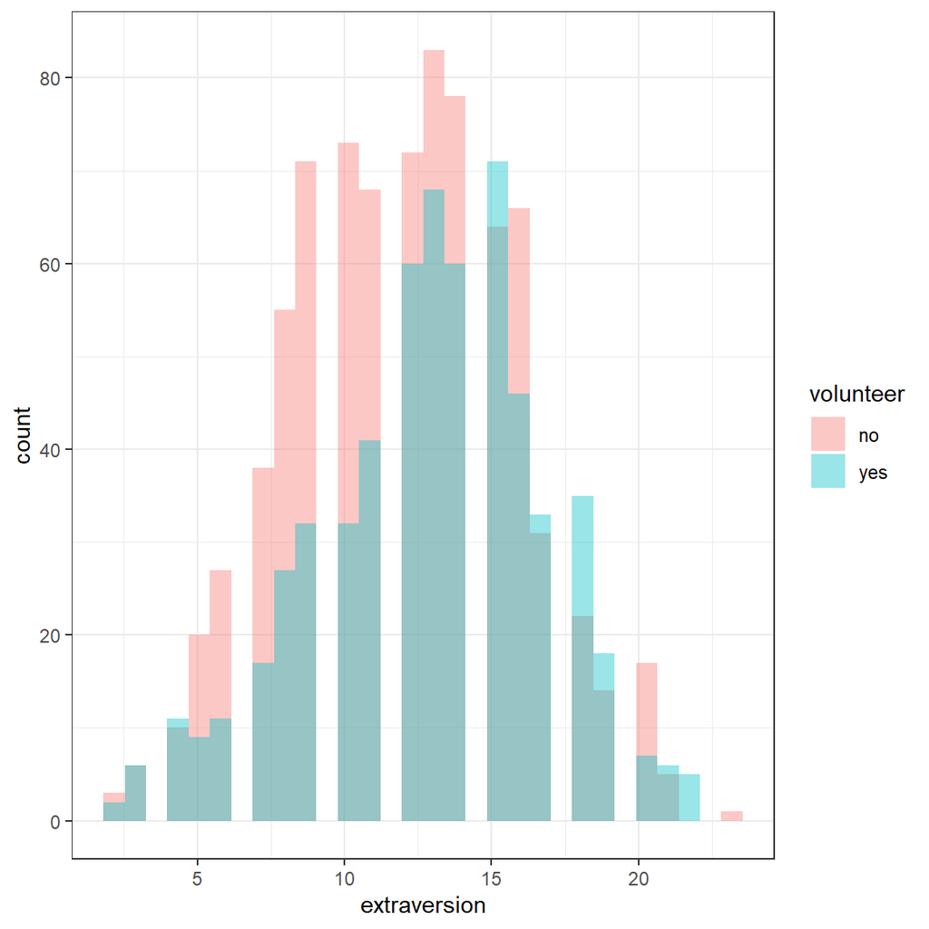

```r
ggplot(Cowles, aes(x = extraversion, fill = volunteer)) +
  geom_histogram(position = "identity", alpha = 0.4)
```

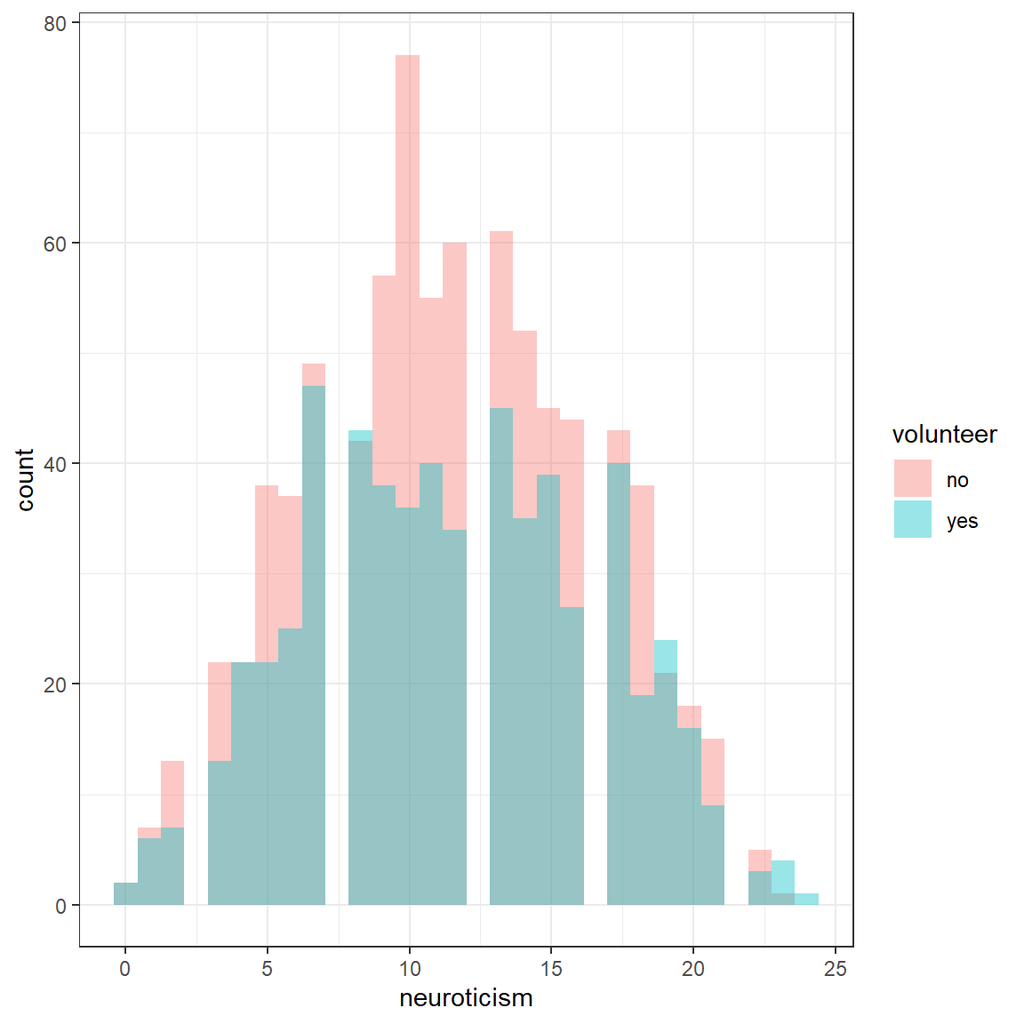

```r
ggplot(Cowles, aes(x = neuroticism, fill = volunteer)) +
  geom_histogram(position = "identity", alpha = 0.4)
```

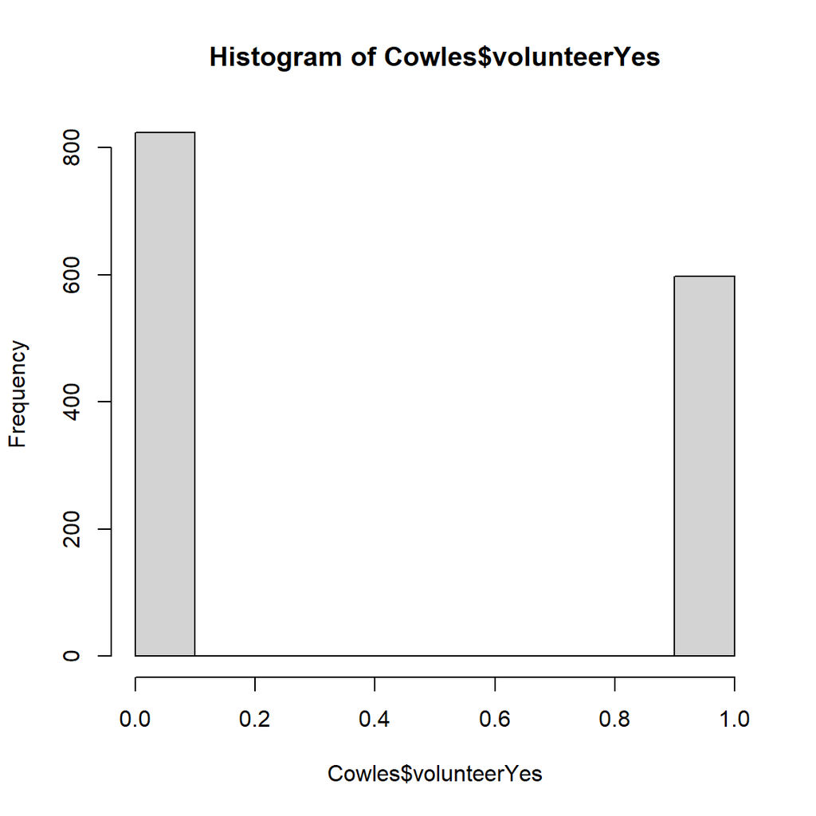

```r
hist(Cowles$volunteerYes)
```

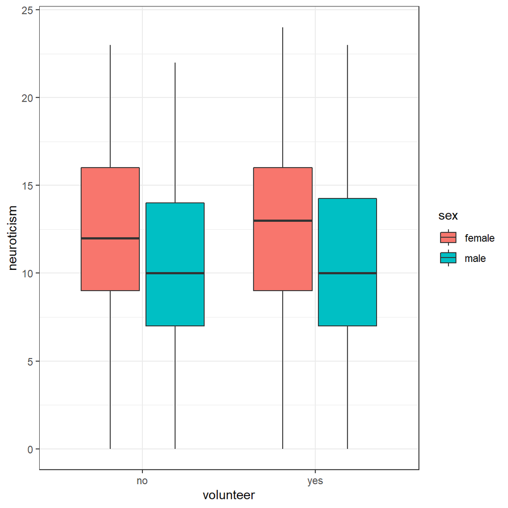

```r
ggplot(Cowles, aes(x=volunteer, y=neuroticism, fill=sex)) +
    geom_boxplot()
```

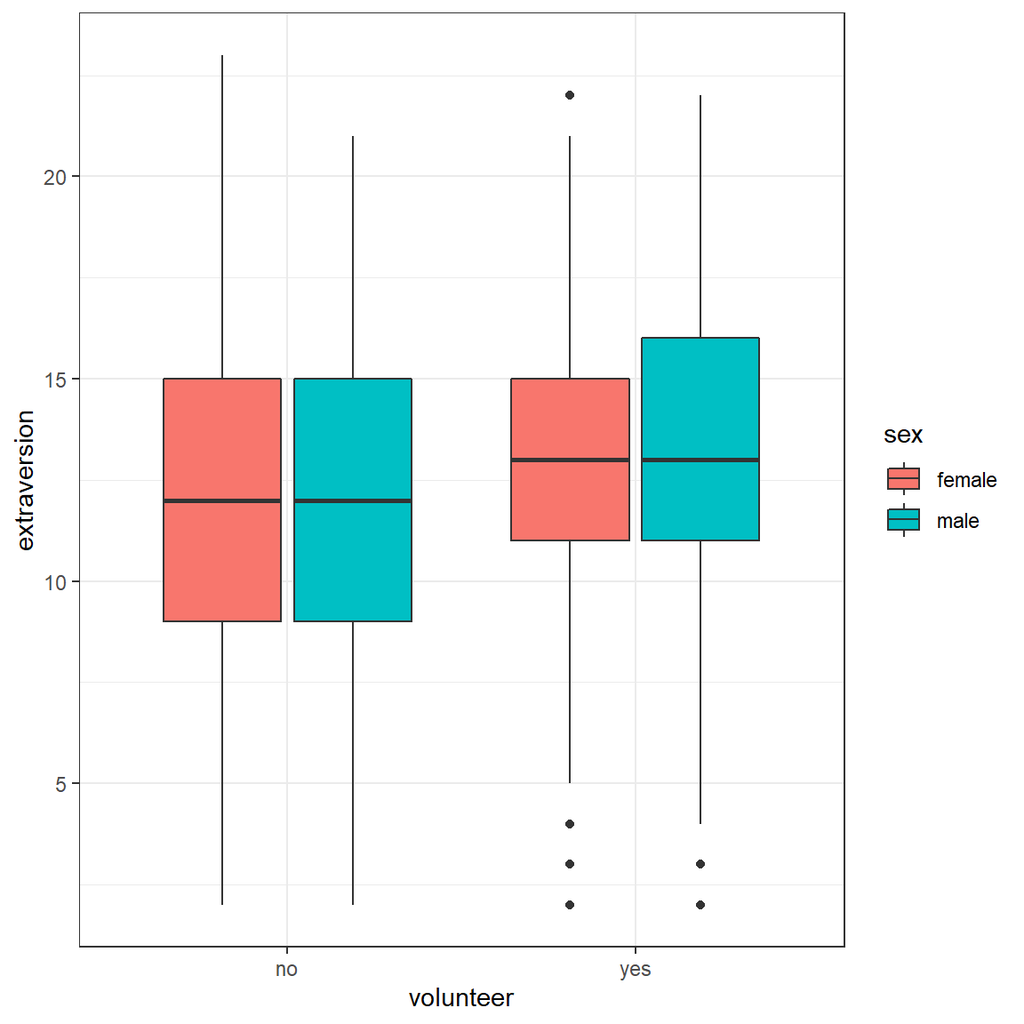

```r
ggplot(Cowles, aes(x=volunteer, y=extraversion, fill=sex)) +
    geom_boxplot()
```

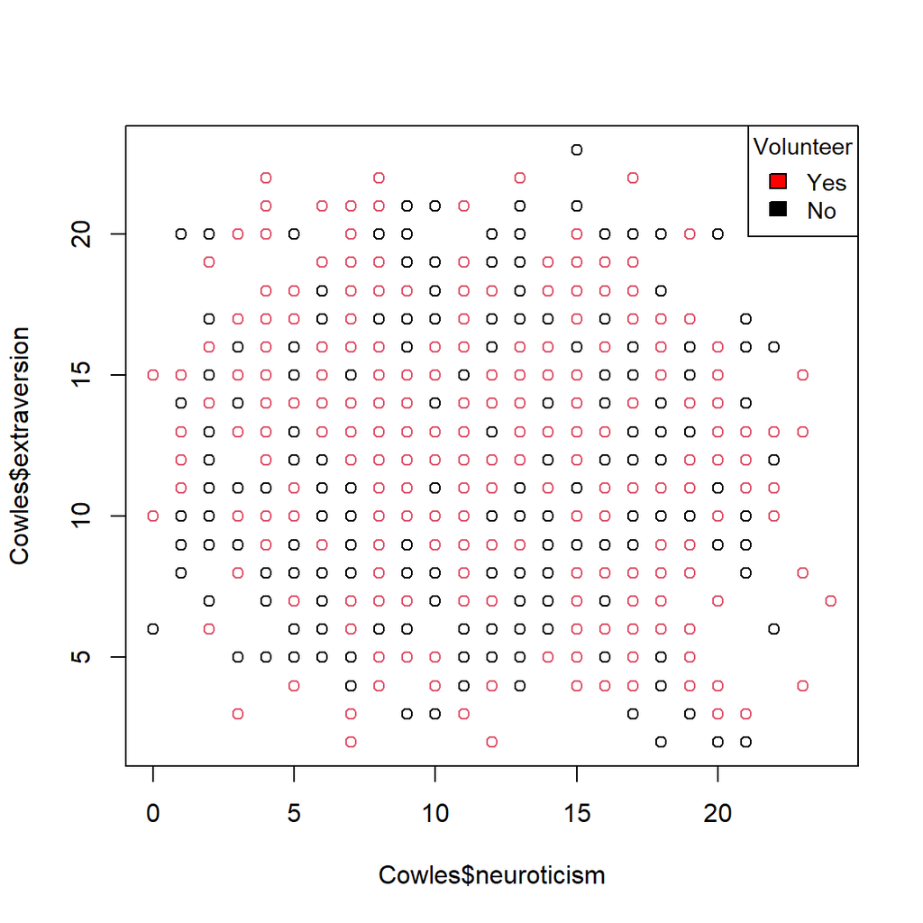

```r
plot(Cowles$neuroticism, Cowles$extraversion, col = Cowles$volunteer)
legend("topright",  title="Volunteer", legend=c("Yes", "No"),
       fill=c("red", "black"), cex=0.9)
```

```r
model <- glm(volunteerYes ~ extraversion + neuroticism + sex, data = Cowles, family = binomial)
summary(model)
```

```
Call:
glm(formula = volunteerYes ~ extraversion + neuroticism + sex,
    family = binomial, data = Cowles)

Deviance Residuals:
    Min       1Q   Median       3Q      Max
-1.3977  -1.0454  -0.9084   1.2601   1.6849

Coefficients:
              Estimate Std. Error z value Pr(>|z|)
(Intercept)  -1.116496   0.249057  -4.483 7.36e-06 ***
extraversion  0.066325   0.014260   4.651 3.30e-06 ***
neuroticism   0.006362   0.011357   0.560   0.5754
sexmale      -0.235161   0.111185  -2.115   0.0344 *
---
Signif. codes:  0 '***' 0.001 '**' 0.01 '*' 0.05 '.' 0.1 ' ' 1

(Dispersion parameter for binomial family taken to be 1)

    Null deviance: 1933.5  on 1420  degrees of freedom
Residual deviance: 1906.1  on 1417  degrees of freedom
AIC: 1914.1

Number of Fisher Scoring iterations: 4
```

Extraversion and sex seem to be significant, but let’s include interactions

```r
model2 <- update(model, ~ extraversion * neuroticism)
summary(model2)
```

```
Call:
glm(formula = volunteerYes ~ extraversion + neuroticism + extraversion:neuroticism,
    family = binomial, data = Cowles)

Deviance Residuals:
    Min       1Q   Median       3Q      Max
-1.5060  -1.0561  -0.9075   1.2758   1.9499

Coefficients:
                          Estimate Std. Error z value Pr(>|z|)
(Intercept)              -2.496334   0.496843  -5.024 5.05e-07 ***
extraversion              0.164797   0.037635   4.379 1.19e-05 ***
neuroticism               0.112498   0.037564   2.995  0.00275 **
extraversion:neuroticism -0.008315   0.002926  -2.842  0.00448 **
---
Signif. codes:  0 '***' 0.001 '**' 0.01 '*' 0.05 '.' 0.1 ' ' 1

(Dispersion parameter for binomial family taken to be 1)

    Null deviance: 1933.5  on 1420  degrees of freedom
Residual deviance: 1902.4  on 1417  degrees of freedom
AIC: 1910.4

Number of Fisher Scoring iterations: 4
```

Significant extraversion:neuroticism interactions.

```r
model3 <- update(model, ~ extraversion * sex)
summary(model3)
```

```
Call:
glm(formula = volunteerYes ~ extraversion + sex + extraversion:sex,
    family = binomial, data = Cowles)

Deviance Residuals:
    Min       1Q   Median       3Q      Max
-1.3814  -1.0505  -0.9019   1.2535   1.6909

Coefficients:
                      Estimate Std. Error z value Pr(>|z|)
(Intercept)          -1.015244   0.251955  -4.029 5.59e-05 ***
extraversion          0.064475   0.019263   3.347 0.000817 ***
sexmale              -0.273971   0.373166  -0.734 0.462840
extraversion:sexmale  0.002181   0.028448   0.077 0.938890
---
Signif. codes:  0 '***' 0.001 '**' 0.01 '*' 0.05 '.' 0.1 ' ' 1

(Dispersion parameter for binomial family taken to be 1)

    Null deviance: 1933.5  on 1420  degrees of freedom
Residual deviance: 1906.4  on 1417  degrees of freedom
AIC: 1914.4

Number of Fisher Scoring iterations: 4
```

```r
model4 <- update(model, ~ neuroticism * sex)
summary(model4)
```

```
Call:
glm(formula = volunteerYes ~ neuroticism + sex + neuroticism:sex,
    family = binomial, data = Cowles)

Deviance Residuals:
   Min      1Q  Median      3Q     Max
-1.106  -1.081  -0.986   1.274   1.396

Coefficients:
                     Estimate Std. Error z value Pr(>|z|)
(Intercept)         -0.258586   0.199412  -1.297    0.195
neuroticism          0.003871   0.015134   0.256    0.798
sexmale             -0.167940   0.276757  -0.607    0.544
neuroticism:sexmale -0.007102   0.022473  -0.316    0.752

(Dispersion parameter for binomial family taken to be 1)

    Null deviance: 1933.5  on 1420  degrees of freedom
Residual deviance: 1928.1  on 1417  degrees of freedom
AIC: 1936.1

Number of Fisher Scoring iterations: 4
```

No significant interactions with sex

We can see that there might be significant effect of extraversion and possibly weaker neuroticism and neuroticism x extraversion interaction effect.

Sex effect is a little weak but the following model seems to be the best

```r
model5 <- glm(volunteerYes ~ extraversion * neuroticism + sex, data = Cowles, family = binomial)
summary(model5)
```

```
Call:
glm(formula = volunteerYes ~ extraversion * neuroticism + sex,
    family = binomial, data = Cowles)

Deviance Residuals:
    Min       1Q   Median       3Q      Max
-1.4749  -1.0602  -0.8934   1.2609   1.9978

Coefficients:
                          Estimate Std. Error z value Pr(>|z|)
(Intercept)              -2.358207   0.501320  -4.704 2.55e-06 ***
extraversion              0.166816   0.037719   4.423 9.75e-06 ***
neuroticism               0.110777   0.037648   2.942  0.00326 **
sexmale                  -0.247152   0.111631  -2.214  0.02683 *
extraversion:neuroticism -0.008552   0.002934  -2.915  0.00355 **
---
Signif. codes:  0 '***' 0.001 '**' 0.01 '*' 0.05 '.' 0.1 ' ' 1

(Dispersion parameter for binomial family taken to be 1)

    Null deviance: 1933.5  on 1420  degrees of freedom
Residual deviance: 1897.4  on 1416  degrees of freedom
AIC: 1907.4

Number of Fisher Scoring iterations: 4
```

```r
(emm <- emmeans(model5, c("extraversion", "neuroticism"), at = list(extraversion = 0:1, neuroticism = 0:1)))
```

```
 extraversion neuroticism emmean    SE  df asymp.LCL asymp.UCL
            0           0  -2.48 0.498 Inf     -3.46     -1.51
            1           0  -2.31 0.462 Inf     -3.22     -1.41
            0           1  -2.37 0.463 Inf     -3.28     -1.46
            1           1  -2.21 0.430 Inf     -3.06     -1.37

Results are averaged over the levels of: sex
Results are given on the logit (not the response) scale.
Confidence level used: 0.95
```

```r
contrast(emm, method = list(
    extraversion = list(
        not.neurotic = c(-1, 1, 0, 0),
        neurotic = c(0, 0, -1, 1)
    )
), type = "response")
```

```
 contrast                  odds.ratio     SE  df null z.ratio p.value
 extraversion.not.neurotic       1.18 0.0446 Inf    1 4.423   <.0001
 extraversion.neurotic           1.17 0.0410 Inf    1 4.519   <.0001

Results are averaged over the levels of: sex
Tests are performed on the log odds ratio scale
```

```r
emmeans(model5, c("extraversion", "neuroticism"), at = list(
    extraversion = c(5, 10, 15, 23),
    neuroticism = c(5, 10, 15, 24)
), type = "response")
```

```
 extraversion neuroticism  prob     SE  df asymp.LCL asymp.UCL
            5           5 0.213 0.0360 Inf     0.151     0.292
           10           5 0.335 0.0258 Inf     0.286     0.387
           15           5 0.483 0.0266 Inf     0.432     0.535
           23           5 0.716 0.0545 Inf     0.599     0.810
            5          10 0.275 0.0267 Inf     0.226     0.331
           10          10 0.363 0.0167 Inf     0.331     0.397
           15          10 0.461 0.0165 Inf     0.429     0.494
           23          10 0.621 0.0393 Inf     0.542     0.695
            5          15 0.348 0.0309 Inf     0.290     0.411
           10          15 0.393 0.0181 Inf     0.358     0.429
           15          15 0.440 0.0212 Inf     0.399     0.482
           23          15 0.517 0.0501 Inf     0.419     0.613
            5          24 0.496 0.0762 Inf     0.351     0.642
           10          24 0.448 0.0418 Inf     0.368     0.531
           15          24 0.401 0.0466 Inf     0.314     0.495
           23          24 0.330 0.1001 Inf     0.169     0.545

Results are averaged over the levels of: sex
Confidence level used: 0.95
Intervals are back-transformed from the logit scale
```

It seems that the biggest impact on volunteering has extraversion, but the more points in neuroticism, the less likely it is that person will volunteer even with high extraversion score

```r
PseudoR2(model5, which = "Nagelkerke")
```

```
Nagelkerke
0.03370673
```

```r
model0 <- update(model5, ~ 1)
lrtest(model5, model0)
```

```
Likelihood ratio test

Model 1: volunteerYes ~ extraversion * neuroticism + sex
Model 2: volunteerYes ~ 1
  #Df  LogLik Df  Chisq Pr(>Chisq)
1   5 -948.72
2   1 -966.75 -4 36.066  2.805e-07 ***
---
Signif. codes:  0 '***' 0.001 '**' 0.01 '*' 0.05 '.' 0.1 ' ' 1
```

```r
model5 %>%
  confint()
```

```
                               2.5 %       97.5 %
(Intercept)              -3.35652914 -1.389154923
extraversion              0.09374678  0.241771712
neuroticism               0.03744357  0.185227757
sexmale                  -0.46642058 -0.028694911
extraversion:neuroticism -0.01434742 -0.002833714
```

Report:

To study which factors were associated with volunteering in psychological research, a logistic regression model was fitted. The response variable (volunteer) was a dichotomous indicator of whether a given person volunteered or not. The predictors were extraversion (integer score in test), neuroticism (integer score in test) and sex (male, female). The model included also an interaction effect in order to study possible extraversion and neuroticism joint effect.

extraversion: 0.166816 (95% CI = [0.09374678, 0.241771712], p-value < 0.05)

neuroticism: 0.110777 (95% CI = [0.03744357, 0.185227757], p-value < 0.05)

sexmale: -0.247152 (95% CI = [-0.46642058, -0.028694911], p-value < 0.05)

extraversion:neuroticism: -0.008552 (95% CI = [-0.01434742, -0.002833714], p-value < 0.05)

## 2. (2 points)

Use `SLID` dataset from `carData` package. It is a dataset for 1994 wave of the Canadian Survey of Labour and Income Dynamics (for the Ontario province). Use it to explain `wages` based on `education`, `age`, `sex` and `language`. Use the model to estimate potential income disparities with respect to `sex` and `language` while controlling for other covariates.

Report your results properly and try to visualize your main findings.

If you transform the response variable you should write down the equation for $\hat{y}_i$ in the original scale.

```r
data(SLID)
SLID <- tibble(SLID)
SLID <- SLID[complete.cases(SLID),]
SLID
```

```
# A tibble: 3,987 x 5
   wages education   age sex    language
   <dbl>     <dbl> <int> <fct>  <fct>
 1 10.6       15      40 Male   English
 2 11         13.2    19 Male   English
 3 17.8       14      46 Male   Other
 4 14         16      50 Female English
 5  8.2       15      31 Male   English
 6 17.0       13.5    30 Female English
 7  6.7       12      61 Female English
 8 14         14      46 Female Other
 9 19.2       18      43 Male   English
10  7.25      11      17 Male   English
# ... with 3,977 more rows
```

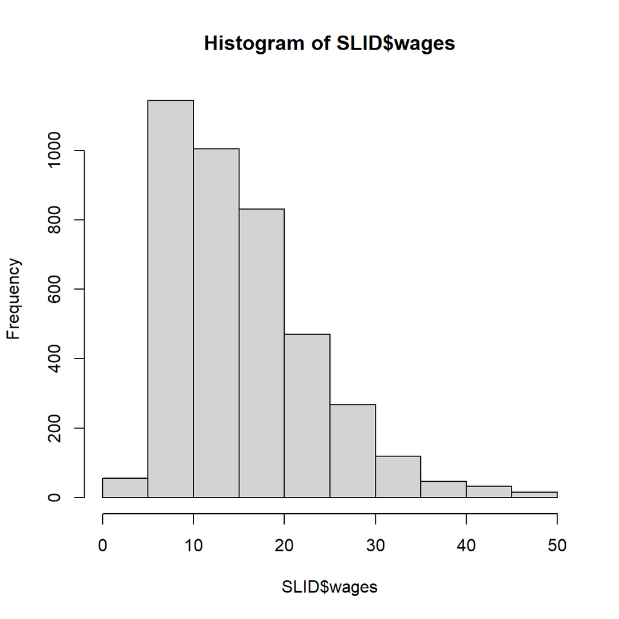

```r
hist(SLID$wages)
```

Residuals:

```r
res <- lm(wages ~ sex * language + education + age, data = SLID)
```

Normality:

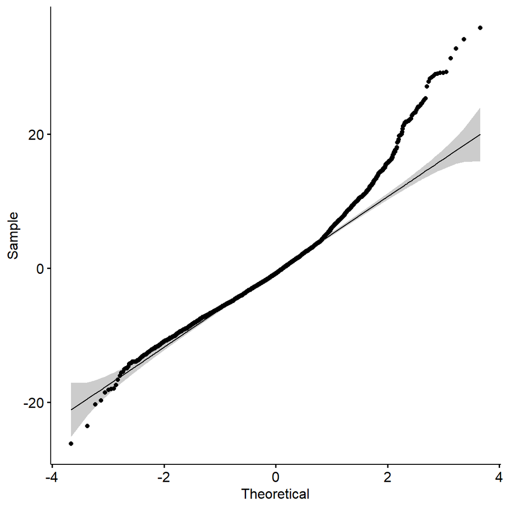

```r
ggqqplot(residuals(res))
```

Homogeneity of residuals:

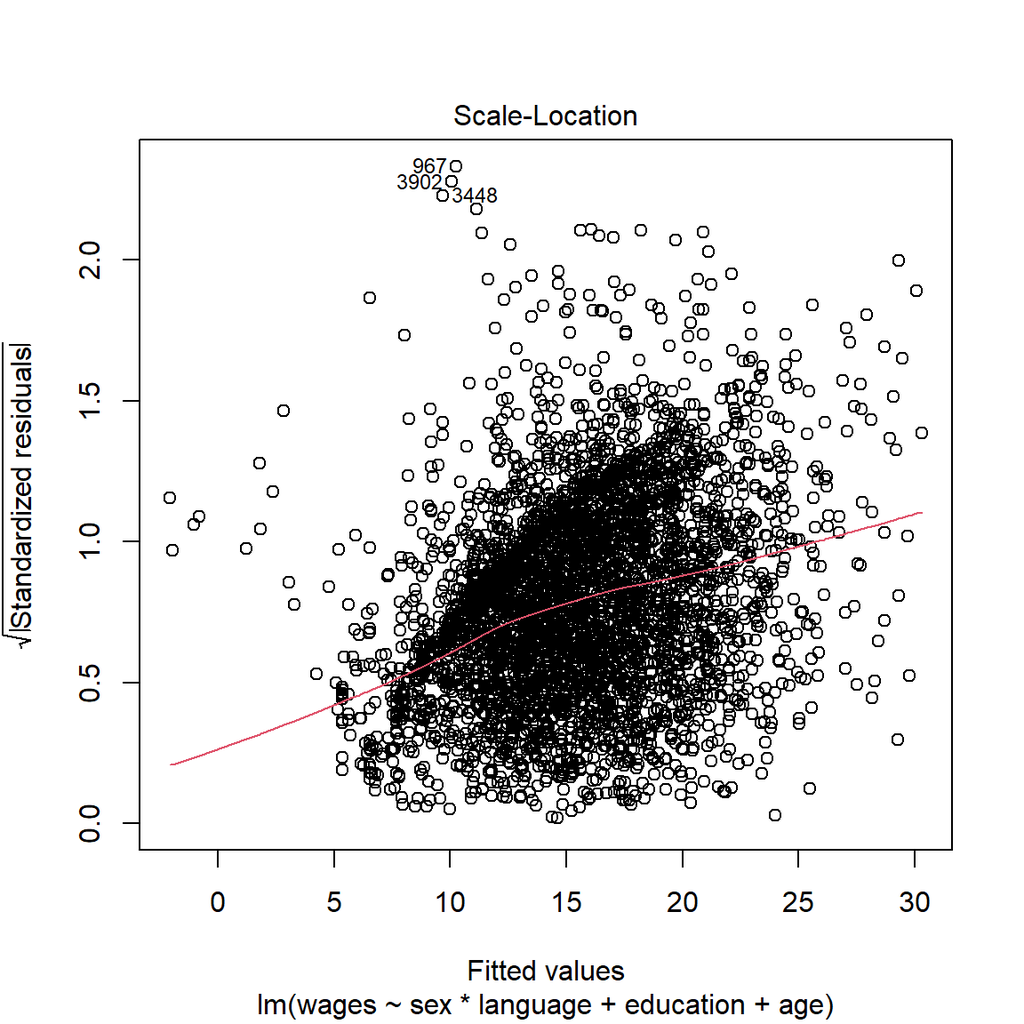

```r
plot(res, 3)
```

Histogram:

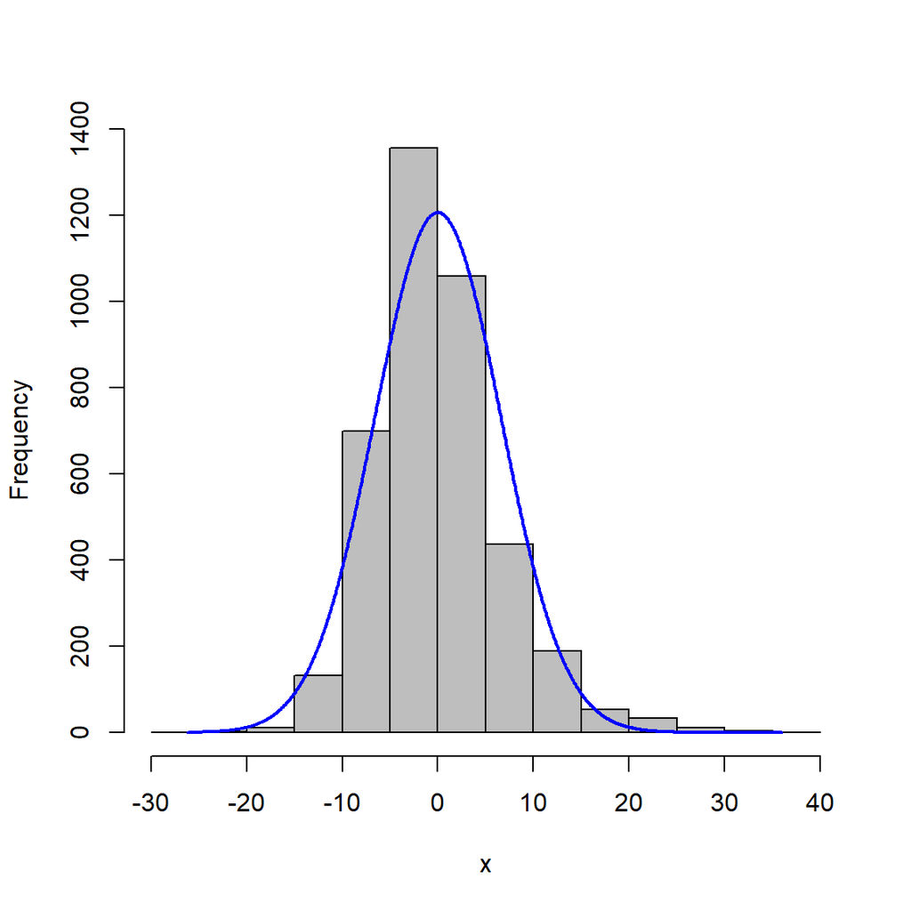

```r
plotNormalHistogram(residuals(res))
```

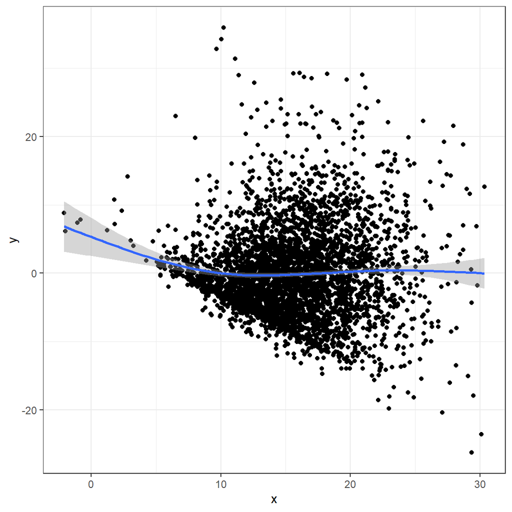

```r
tibble(
    x = fitted(res),
    y = resid(res)
) %>%
    ggplot(aes(x = x, y = y)) +
    geom_point() +
    geom_smooth(method = "gam")
```

```r
skewness(SLID$wages)
```

```
[1] 1.059096
```

‘wages’ variable is right-skewed. We should apply log transformation

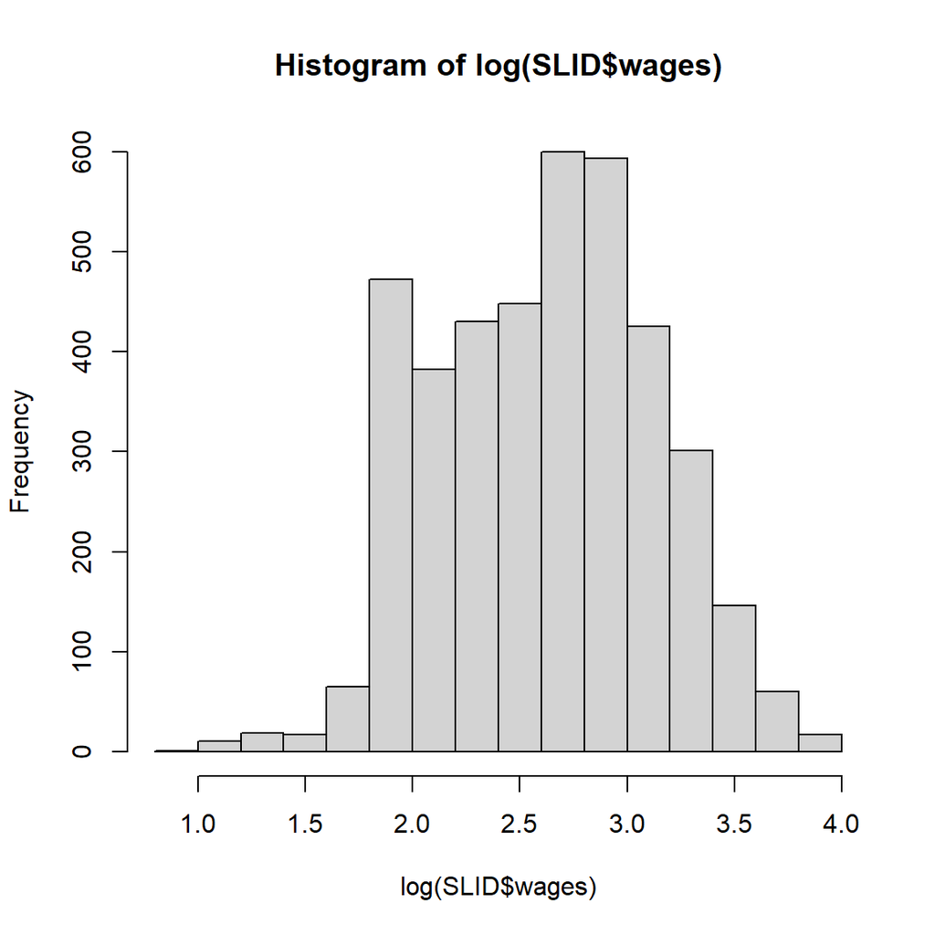

```r
hist(log(SLID$wages))
```

```r
skewness(log(SLID$wages))
```

```
[1] -0.06082738
```

It is fine now

```r
model <- lm(wages ~ sex * language + education + age, data = SLID)
summary(model)
```

```
Call:
lm(formula = wages ~ sex * language + education + age, data = SLID)

Residuals:
    Min      1Q  Median      3Q     Max
-26.202  -4.347  -0.809   3.233  35.912

Coefficients:
                        Estimate Std. Error t value Pr(>|t|)
(Intercept)            -7.885033   0.614946 -12.822   <2e-16 ***
sexMale                 3.447631   0.231880  14.868   <2e-16 ***
languageFrench         -0.183573   0.627023  -0.293    0.770
languageOther           0.192689   0.453344   0.425    0.671
education               0.916628   0.034770  26.363   <2e-16 ***
age                     0.255135   0.008719  29.263   <2e-16 ***
sexMale:languageFrench  0.312109   0.855232   0.365    0.715
sexMale:languageOther  -0.101872   0.643621  -0.158    0.874
---
Signif. codes:  0 '***' 0.001 '**' 0.01 '*' 0.05 '.' 0.1 ' ' 1

Residual standard error: 6.602 on 3979 degrees of freedom
Multiple R-squared:  0.2973,    Adjusted R-squared:  0.2961
F-statistic: 240.5 on 7 and 3979 DF,  p-value: < 2.2e-16
```

```r
model1 <- lm(log(wages) ~ sex * language + education + age, data = SLID)
summary(model1)
```

```
Call:
lm(formula = log(wages) ~ sex * language + education + age, data = SLID)

Residuals:
     Min       1Q   Median       3Q      Max
-2.36190 -0.27751  0.01398  0.28552  1.56483

Coefficients:
                         Estimate Std. Error t value Pr(>|t|)
(Intercept)             1.1162025  0.0389958  28.624   <2e-16 ***
sexMale                 0.2281702  0.0147043  15.517   <2e-16 ***
languageFrench          0.0101754  0.0397616   0.256    0.798
languageOther           0.0231244  0.0287480   0.804    0.421
education               0.0550321  0.0022049  24.959   <2e-16 ***
age                     0.0176301  0.0005529  31.888   <2e-16 ***
sexMale:languageFrench -0.0100663  0.0542331  -0.186    0.853
sexMale:languageOther  -0.0268896  0.0408142  -0.659    0.510
---
Signif. codes:  0 '***' 0.001 '**' 0.01 '*' 0.05 '.' 0.1 ' ' 1

Residual standard error: 0.4186 on 3979 degrees of freedom
Multiple R-squared:  0.3096,    Adjusted R-squared:  0.3084
F-statistic: 254.9 on 7 and 3979 DF,  p-value: < 2.2e-16
```

Language doesn’t have significant effect, so I omit this variable to make the best possible model

```r
model2 <- lm(log(wages) ~ sex + education + age, data = SLID)
summary(model2)
```

```
Call:
lm(formula = log(wages) ~ sex + education + age, data = SLID)

Residuals:
     Min       1Q   Median       3Q      Max
-2.36116 -0.27682  0.01416  0.28530  1.56545

Coefficients:
             Estimate Std. Error t value Pr(>|t|)
(Intercept) 1.1201866  0.0386324   29.00   <2e-16 ***
sexMale     0.2242567  0.0132600   16.91   <2e-16 ***
education   0.0549349  0.0021947   25.03   <2e-16 ***
age         0.0176509  0.0005492   32.14   <2e-16 ***
---
Signif. codes:  0 '***' 0.001 '**' 0.01 '*' 0.05 '.' 0.1 ' ' 1

Residual standard error: 0.4185 on 3983 degrees of freedom
Multiple R-squared:  0.3095,    Adjusted R-squared:  0.3089
F-statistic:   595 on 3 and 3983 DF,  p-value: < 2.2e-16
```

Residual standard error decreased, ‘wages’ is not skewed anymore, so the model seems alright.

There are no interactions and sex, education and age effects are significant.

```r
etasq(model2, anova = TRUE, partial = TRUE, type = 2)
```

```
Anova Table (Type II tests)

Response: log(wages)
          Partial eta^2 Sum Sq   Df F value    Pr(>F)
sex             0.06700  50.09    1  286.03 < 2.2e-16 ***
education       0.13592 109.71    1  626.51 < 2.2e-16 ***
age             0.20590 180.85    1 1032.75 < 2.2e-16 ***
Residuals               697.49 3983
---
Signif. codes:  0 '***' 0.001 '**' 0.01 '*' 0.05 '.' 0.1 ' ' 1
```

Estimation of main effect of sex, education and age without presence of interactions

```r
pairs(emmeans(model2, "sex")) %>%
    confint
```

```
 contrast      estimate     SE   df lower.CL upper.CL
 Female - Male   -0.224 0.0133 3983    -0.25   -0.198

Results are given on the log (not the response) scale.
Confidence level used: 0.95
```

```r
emmeans(model2, "education") %>%
    confint
```

```
 education emmean       SE   df lower.CL upper.CL
     13.34   2.62 0.006627 3983    2.607    2.633

Results are averaged over the levels of: sex
Results are given on the log (not the response) scale.
Confidence level used: 0.95
```

```r
emmeans(model2, "age") %>%
    confint
```

```
  age emmean       SE   df lower.CL upper.CL
 37.1   2.62 0.006627 3983    2.607    2.633

Results are averaged over the levels of: sex
Results are given on the log (not the response) scale.
Confidence level used: 0.95
```

Report:

$$log(\hat{y_i}) = 1.1201866 + 0.2242567*x1_i + 0.0549349*x2_i + 0.0176509*x3_i
\\\hat{y_i} = e^{1.1201866}e^{0.2242567*x1_i}e^ {0.0549349*x2_i} e^{0.0176509*x3_i}$$

($x1$ - sex, $x2$ - education, $x3$ - age)

## 3. (2 points)

Use `Baumann` data from `carData` package. It is a dataset with results of an experiment on the efficacy of three different teaching methods (`group` variables). Subjects were assigned randomly to experimental groups. Your response variable should be differences between post- and pre-tests (only $1$ and $2$, ignore post-test $3$).

Estimate the efficacy of different methods. Remember that there are two measurements per subject. Report your results properly and try to visualize them.

Are there both between-subject and within-subject effects here? If yes, then which is which?

```r
data(Baumann)
(Baumann <- tibble(Baumann))
```

```
# A tibble: 66 x 6
   group pretest.1 pretest.2 post.test.1 post.test.2 post.test.3
   <fct>     <int>     <int>       <int>       <int>       <int>
 1 Basal         4         3           5           4          41
 2 Basal         6         5           9           5          41
 3 Basal         9         4           5           3          43
 4 Basal        12         6           8           5          46
 5 Basal        16         5          10           9          46
 6 Basal        15        13           9           8          45
 7 Basal        14         8          12           5          45
 8 Basal        12         7           5           5          32
 9 Basal        12         3           8           7          33
10 Basal         8         8           7           7          39
# ... with 56 more rows
```

```r
D <- Baumann %>%
    transmute(
        group = group,
        subject = row_number(),
        x1 = post.test.1 - pretest.1,
        x2 = post.test.2 - pretest.2
    ) %>%
    pivot_longer(x1:x2)
```

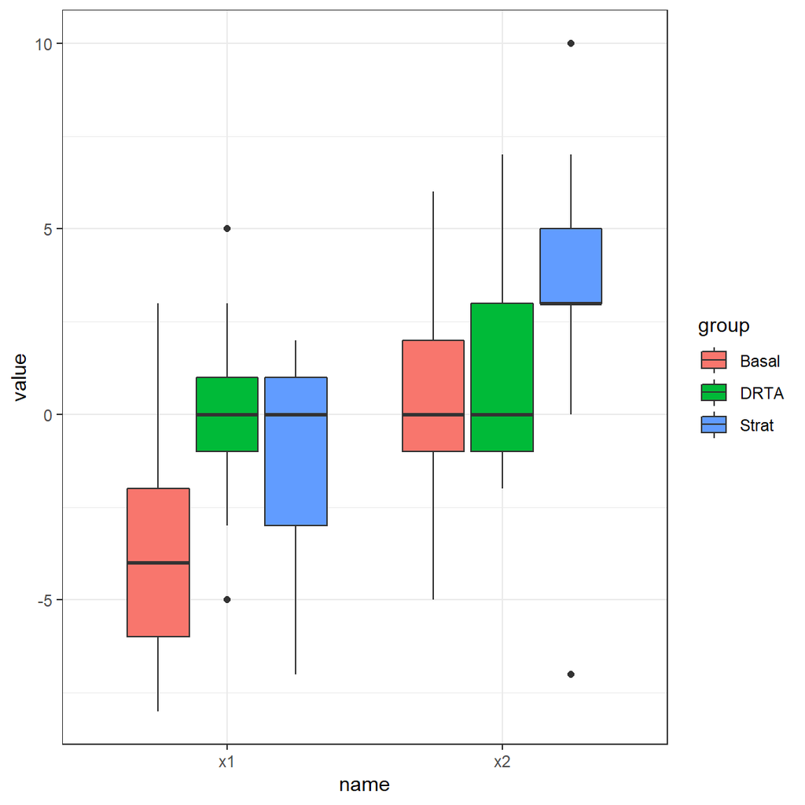

```r
ggplot(D, aes(x=name, y=value, fill=group)) +
    geom_boxplot()
```

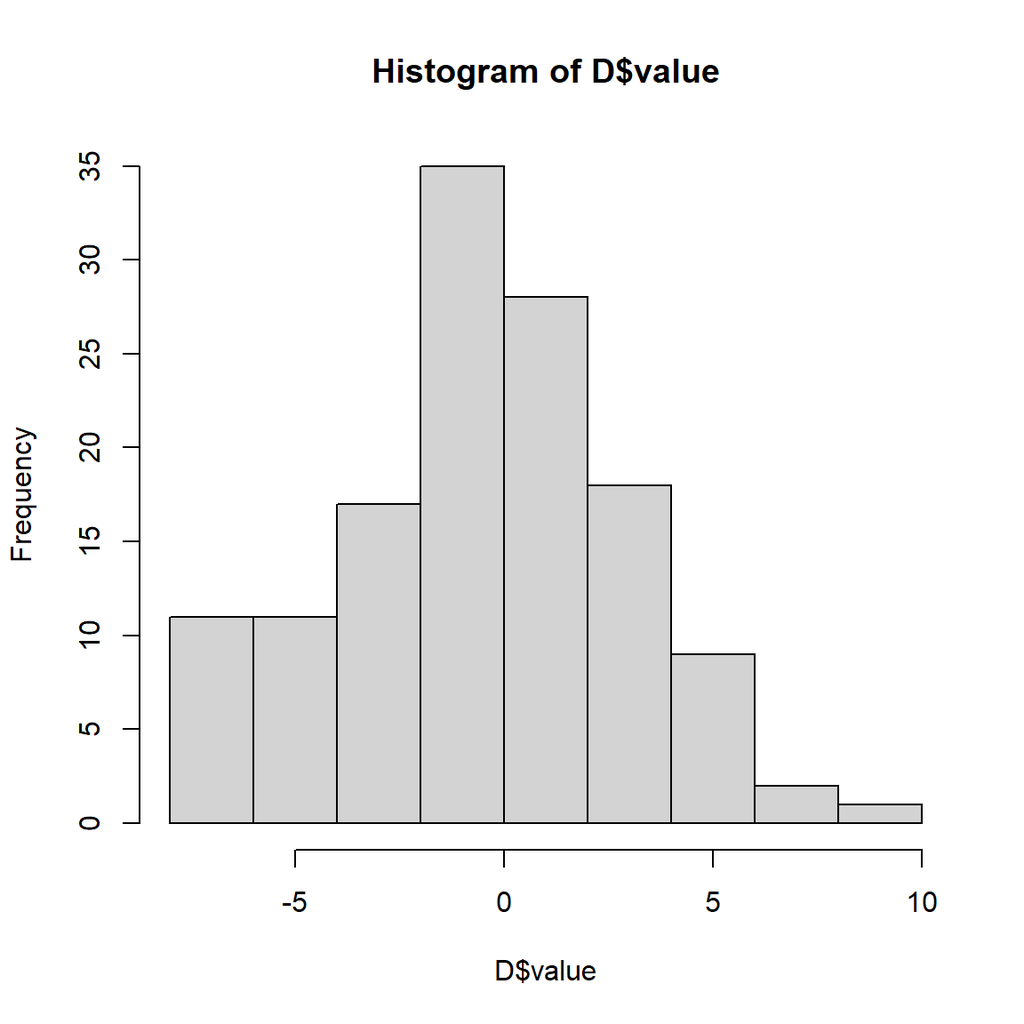

```r
hist(D$value)
```

Residuals:

```r
res <- lmer(value ~ (1 | subject) + group * name, data = D)
```

Normality:

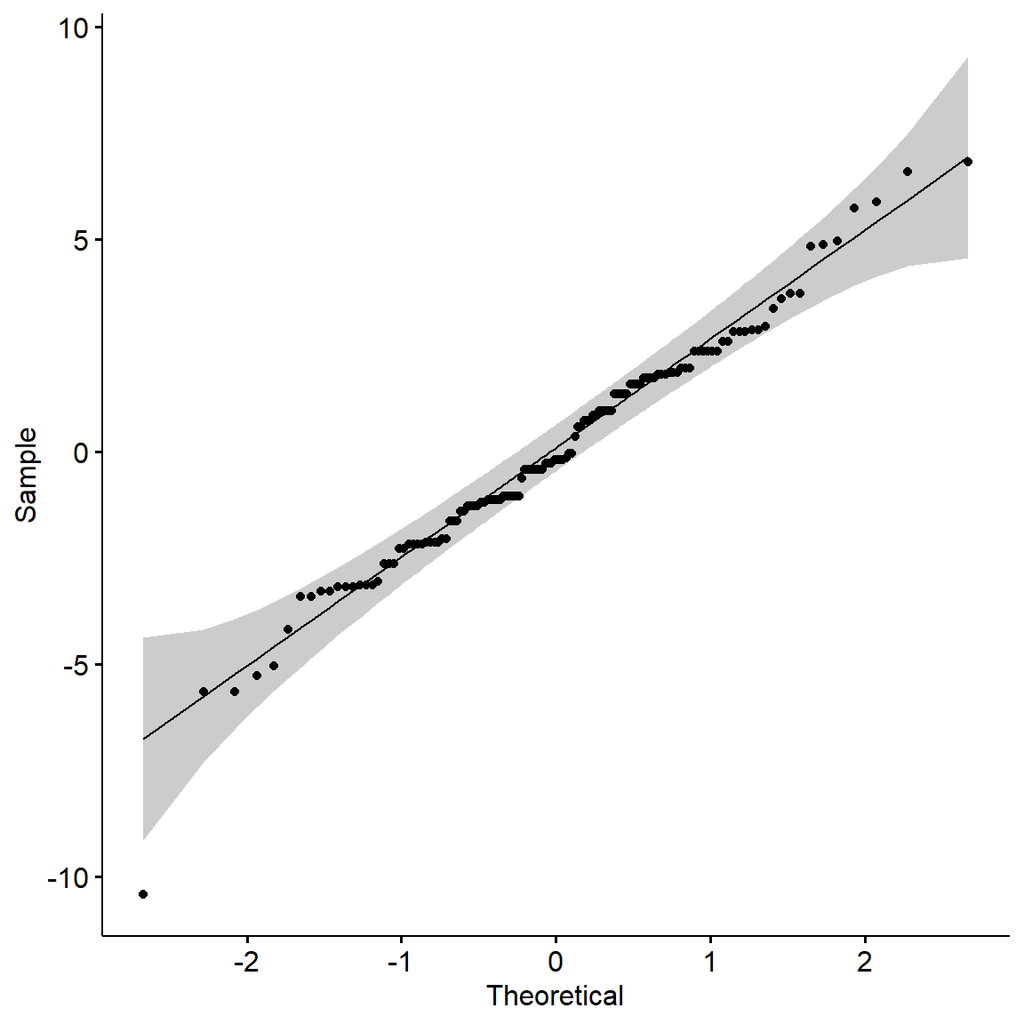

```r
ggqqplot(residuals(res))
```

Histogram of residuals:

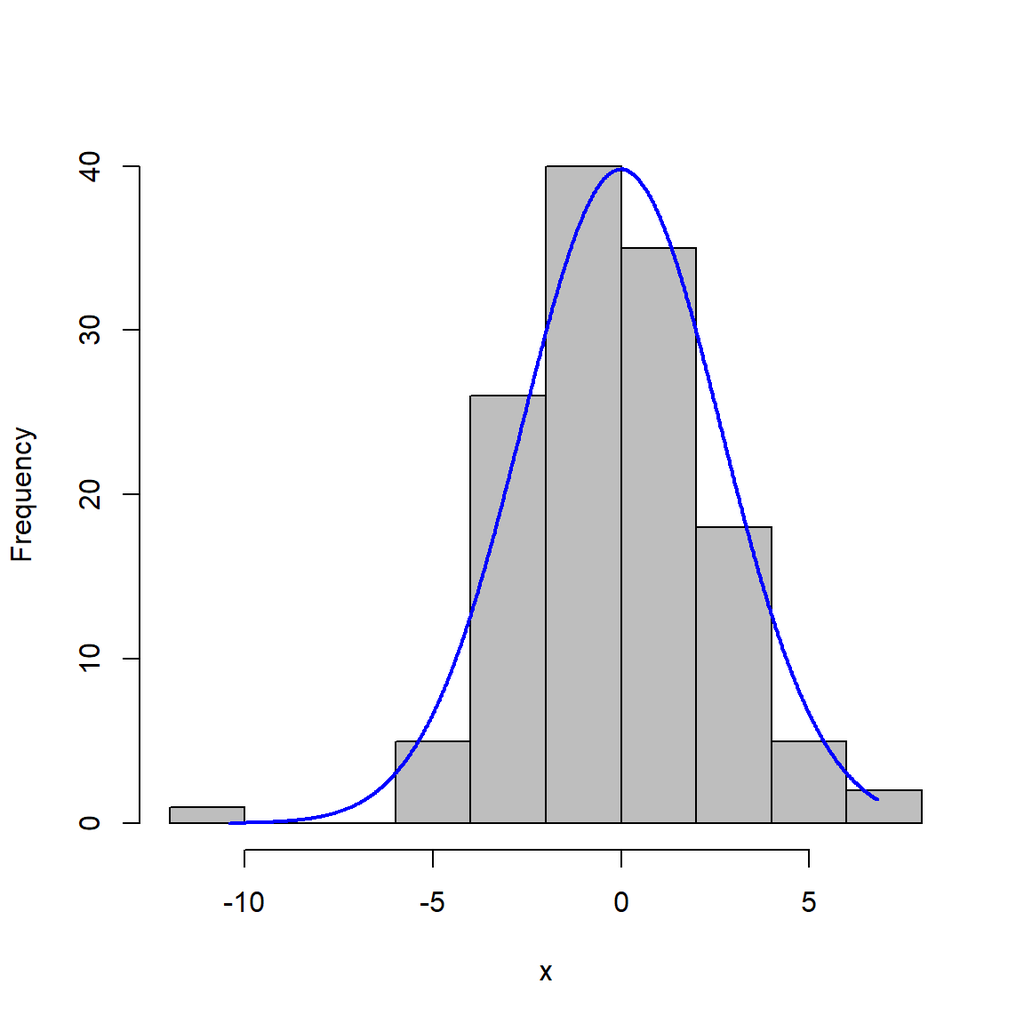

```r
plotNormalHistogram(residuals(res))
```

```r
model <- lmer(value ~ (1 | subject) + group * name, data = D)
summary(model)
```

```
Linear mixed model fit by REML. t-tests use Satterthwaite's method [
lmerModLmerTest]
Formula: value ~ (1 | subject) + group * name
   Data: D

REML criterion at convergence: 626.3

Scaled residuals:
    Min      1Q  Median      3Q     Max
-3.8572 -0.6064 -0.0674  0.6737  2.5266

Random effects:
 Groups   Name        Variance Std.Dev.
 subject  (Intercept) 0.000    0.000
 Residual             7.282    2.699
Number of obs: 132, groups:  subject, 66

Fixed effects:
                  Estimate Std. Error       df t value Pr(>|t|)
(Intercept)        -3.8182     0.5753 126.0000  -6.636 8.58e-10 ***
groupDRTA           3.8636     0.8137 126.0000   4.748 5.48e-06 ***
groupStrat          2.4545     0.8137 126.0000   3.017  0.00309 **
namex2              4.0909     0.8137 126.0000   5.028 1.66e-06 ***
groupDRTA:namex2   -3.0000     1.1507 126.0000  -2.607  0.01023 *
groupStrat:namex2   0.6818     1.1507 126.0000   0.593  0.55456
---
Signif. codes:  0 '***' 0.001 '**' 0.01 '*' 0.05 '.' 0.1 ' ' 1

Correlation of Fixed Effects:
            (Intr) grDRTA grpStr namex2 gDRTA:
groupDRTA   -0.707
groupStrat  -0.707  0.500
namex2      -0.707  0.500  0.500
grpDRTA:nm2  0.500 -0.707 -0.354 -0.707
grpStrt:nm2  0.500 -0.354 -0.707 -0.707  0.500
optimizer (nloptwrap) convergence code: 0 (OK)
boundary (singular) fit: see ?isSingular
```

```r
ranova(model)
```

```
ANOVA-like table for random-effects: Single term deletions

Model:
value ~ group + name + (1 | subject) + group:name
              npar  logLik    AIC LRT Df Pr(>Chisq)
<none>           8 -313.14 642.29
(1 | subject)    7 -313.14 640.29   0  1          1
```

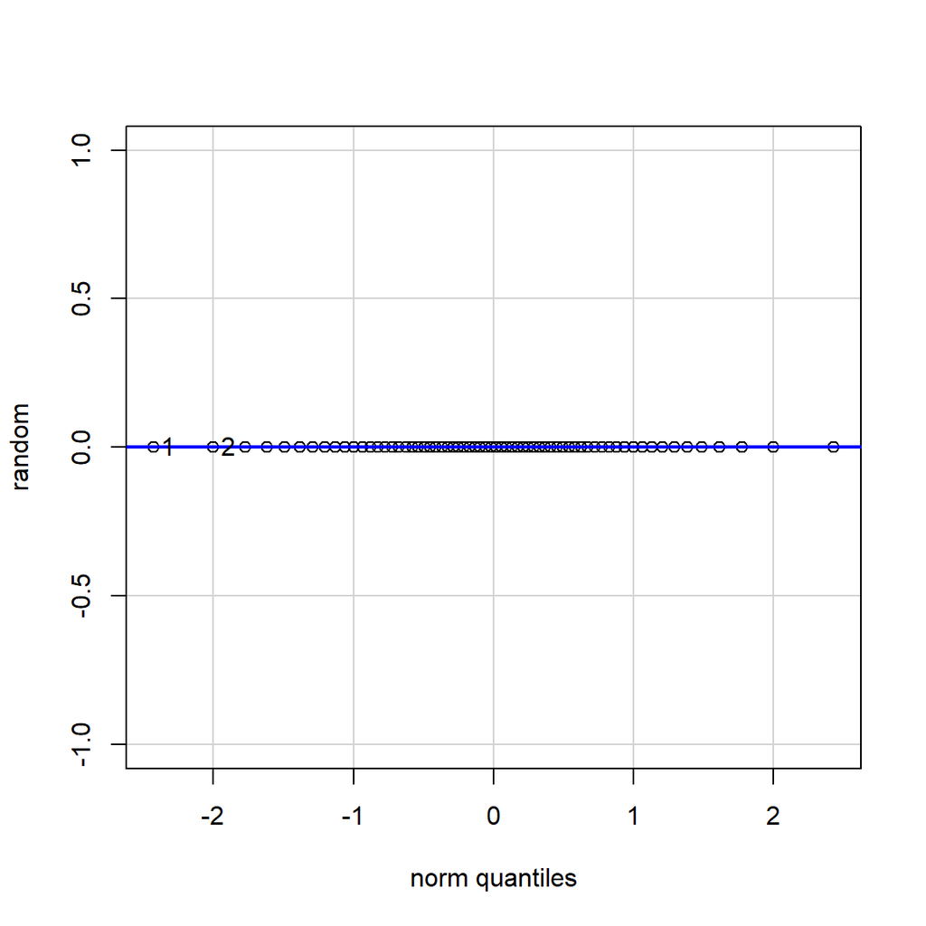

```
[1] 1 2
```

```r
random <- ranef(model)$subject[["(Intercept)"]]
qqPlot(random)
```

Random effects: Variance of subject-specific intercept components is clearly equal to 0 even without additional tests, so individual subject differences do not explain response variation.

```r
Anova(model, type = 2)
```

```
Analysis of Deviance Table (Type II Wald chisquare tests)

Response: value
            Chisq Df Pr(>Chisq)
group      27.365  2  1.142e-06 ***
name       49.893  1  1.624e-12 ***
group:name 11.591  2   0.003042 **
---
Signif. codes:  0 '***' 0.001 '**' 0.01 '*' 0.05 '.' 0.1 ' ' 1
```

Fixed effects: There are significant interactions, so simple effects tests are needed. Both group and name are significant

```r
(emm <- emmeans(model, c("group", "name")))
```

```
 group name  emmean    SE  df lower.CL upper.CL
 Basal x1   -3.8182 0.575 126 -4.95677   -2.680
 DRTA  x1    0.0455 0.575 126 -1.09313    1.184
 Strat x1   -1.3636 0.575 126 -2.50223   -0.225
 Basal x2    0.2727 0.575 126 -0.86586    1.411
 DRTA  x2    1.1364 0.575 126 -0.00223    2.275
 Strat x2    3.4091 0.575 126  2.27050    4.548

Degrees-of-freedom method: kenward-roger
Confidence level used: 0.95
```

```r
(posthoc <- contrast(emm, method = "pairwise", adjust = "holm"))
```

```
 contrast            estimate    SE  df t.ratio p.value
 Basal x1 - DRTA x1    -3.864 0.814 126 -4.748  0.0001
 Basal x1 - Strat x1   -2.455 0.814 126 -3.017  0.0216
 Basal x1 - Basal x2   -4.091 0.814  63 -5.028  0.0001
 Basal x1 - DRTA x2    -4.955 0.814 126 -6.089  <.0001
 Basal x1 - Strat x2   -7.227 0.814 126 -8.882  <.0001
 DRTA x1 - Strat x1     1.409 0.814 126  1.732  0.3430
 DRTA x1 - Basal x2    -0.227 0.814 126 -0.279  0.7805
 DRTA x1 - DRTA x2     -1.091 0.814  63 -1.341  0.5545
 DRTA x1 - Strat x2    -3.364 0.814 126 -4.134  0.0006
 Strat x1 - Basal x2   -1.636 0.814 126 -2.011  0.2322
 Strat x1 - DRTA x2    -2.500 0.814 126 -3.073  0.0208
 Strat x1 - Strat x2   -4.773 0.814  63 -5.866  <.0001
 Basal x2 - DRTA x2    -0.864 0.814 126 -1.061  0.5811
 Basal x2 - Strat x2   -3.136 0.814 126 -3.855  0.0017
 DRTA x2 - Strat x2    -2.273 0.814 126 -2.793  0.0362

Degrees-of-freedom method: kenward-roger
P value adjustment: holm method for 15 tests
```

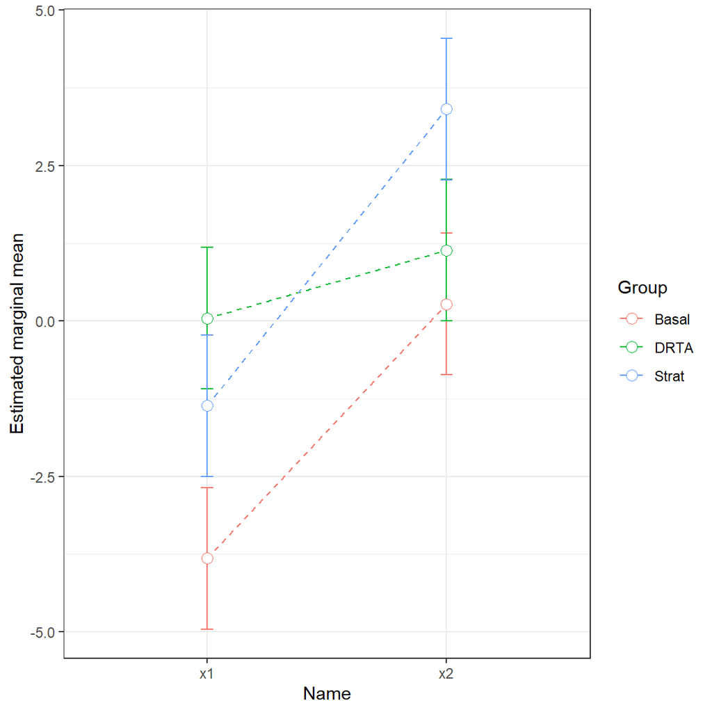

```r
emm %>%
    tidy(conf.int = TRUE) %>%
    ggplot(aes(x = name, y = estimate, group = group, color = group)) +
    geom_line(linetype = 2) +
    geom_errorbar(aes(ymin = conf.low, ymax = conf.high), width = .05) +
    geom_point(shape = 21, fill = "white", size = 3) +
    labs(x = "Name", y = "Estimated marginal mean", color = "Group")
```

```r
(emm2 <- emmeans(model, "group", by = "name"))
```

```
name = x1:
 group  emmean    SE  df lower.CL upper.CL
 Basal -3.8182 0.575 126 -4.95677   -2.680
 DRTA   0.0455 0.575 126 -1.09313    1.184
 Strat -1.3636 0.575 126 -2.50223   -0.225

name = x2:
 group  emmean    SE  df lower.CL upper.CL
 Basal  0.2727 0.575 126 -0.86586    1.411
 DRTA   1.1364 0.575 126 -0.00223    2.275
 Strat  3.4091 0.575 126  2.27050    4.548

Degrees-of-freedom method: kenward-roger
Confidence level used: 0.95
```

```r
contrast(emm2, method = "pairwise", adjust = "holm")
```

```
name = x1:
 contrast      estimate    SE  df t.ratio p.value
 Basal - DRTA    -3.864 0.814 126 -4.748  <.0001
 Basal - Strat   -2.455 0.814 126 -3.017  0.0062
 DRTA - Strat     1.409 0.814 126  1.732  0.0858

name = x2:
 contrast      estimate    SE  df t.ratio p.value
 Basal - DRTA    -0.864 0.814 126 -1.061  0.2905
 Basal - Strat   -3.136 0.814 126 -3.855  0.0006
 DRTA - Strat    -2.273 0.814 126 -2.793  0.0121

Degrees-of-freedom method: kenward-roger
P value adjustment: holm method for 3 tests
```

In the first measurement, DRTA has clearly the biggest, but not significant value, but in the second measurement Strat takes the lead.

```r
r.squaredGLMM(model)
```

```
           R2m       R2c
[1,] 0.4041357 0.4041357
```

Random effects - within subject effects are 0 and do not contribute to variance explanation. Between subject effects - fixed effects - alone explain variance in a somewhat good way.

```r
ctr <- tidy(pairs(emm2, reverse = TRUE))
eff <- tidy(eff_size(emm2, sigma = sigma(model), edf = df.residual(model)))
ctr$cohen <- eff$estimate
ctr$cohen
```

```
[1] -1.4317163 -0.9095609  0.5221554 -0.3200307 -1.1622168 -0.8421861
```

Report:

To study which learning strategy is most effective, an experimental study has been conducted. The response variable (value) was a continuous score in post test. The subjects were split into three groups (Basal, DRTA, Strat) and measured in pre- and post tests. The mixed model was fixed controlling within- and between-subject effects. Random effects analysis indicates that individual differences between subjects were not significant (subject variance: 0, ranova test p-value = 1). Fixed effects analysis revealed that interaction between group and measurement number is significant, so post-hoc tests were conducted.

Post-hoc test studied differences between groups split by measurement. It showed that some learning system mattered in both measurements. In the first one, difference between Basal and DRTA and Basal with Strat was significant, indicating that Basal is significantly lower than other. In the second measurement, difference between Basal and Strat and DRTA with Strat was significant, suggesting that Strat is significantly bigger than other methods.

Detailed results with estimate, p-value and Cohen’s D:

Name = x1:

Basal - DRTA: -3.864 (p-value: <.0001, Cohen’s D: -1.4317163)

Basal - Strat: -2.455 (p-value: 0.0062, Cohen’s D: -0.9095609)

DRTA - Strat: 1.409 (p-value: 0.0858, Cohen’s D: 0.5221554)

Name = x2:

Basal - DRTA: -0.864 (p-value: 0.2905, Cohen’s D: -0.3200307)

Basal - Strat: -3.136 (p-value: 0.0006, Cohen’s D: -1.1622168)

DRTA - Strat: -2.273 (p-value: 0.0121, Cohen’s D: -0.8421861)

Marginal $R^2 = 0.4041357$ indicates that 40% of variance of the response is explained by fixed effects. Conditional $R^2 = 0.4041357$ same as marginal $R^2$ suggests that random effects, so within-subject effects do not play a role in explaining variance of the response variable.

## 4. (2 points)

Use `Wool` dataset from `carData` package. It is an experiment on the durability of wool fabric under different conditions. The experiment has three factors (see `?Wool`). The response variable is `cycles` and experimental factors are `len`, `amp` and `load`.

The problem is that there is only one observation per each combination of levels of the factors. Thus, it is not possible to fit a full-factorial ANOVA model and obtain valid standard errors. You will have to use a different strategy.

The levels of factors are actually numeric, so instead of a typical ANOVA you may fit a standard linear model with continuous predictors (and possibly with interactions). However, remember that it is still an experiment, and in fact a balanced one, so you may use this fact to calculate very informative effect size measures for all factors (to see this calculate linear correlations between `len`, `amp` and `load`).

Moreover, examine the distribution of the response as well as model residuals. If needed, you should consider a transformation of the response. As always, in the case of a transformed response, you should report your results in a way allows the reader to understand your results on the original scale of the response variable. In particular, you may try to visualize your results in the original scale.

In general, try to report your results in a way that will allow to understand the results of the experiment.

```r
data(Wool)
Wool <- tibble(Wool)

# THE DESIGN OF THE EXPERIMENT; ONLY ONE OBSERVATION PER CONDITIOn
with(Wool, table(amp, load, len))
```

```
, , len = 250

    load
amp  40 45 50
  8   1  1  1
  9   1  1  1
  10  1  1  1

, , len = 300

    load
amp  40 45 50
  8   1  1  1
  9   1  1  1
  10  1  1  1

, , len = 350

    load
amp  40 45 50
  8   1  1  1
  9   1  1  1
  10  1  1  1
```

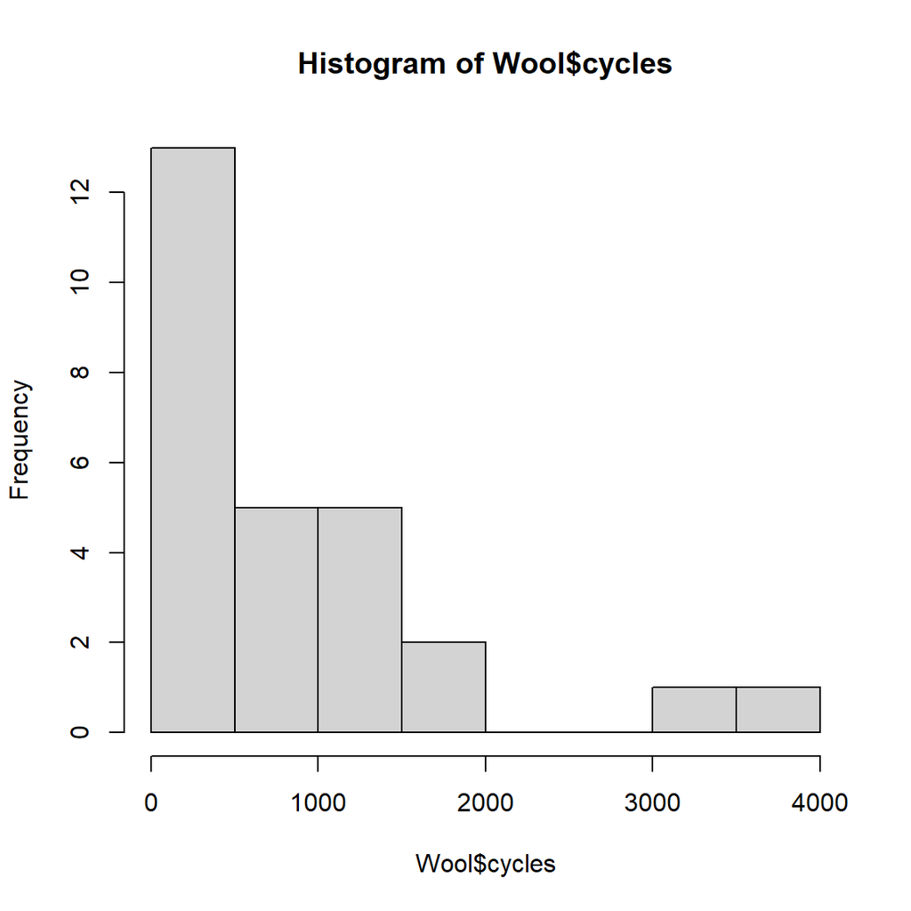

```r
hist(Wool$cycles)
```

Residuals:

```r
res <- lm(cycles ~ len * amp * load, data = Wool)
```

Normality:

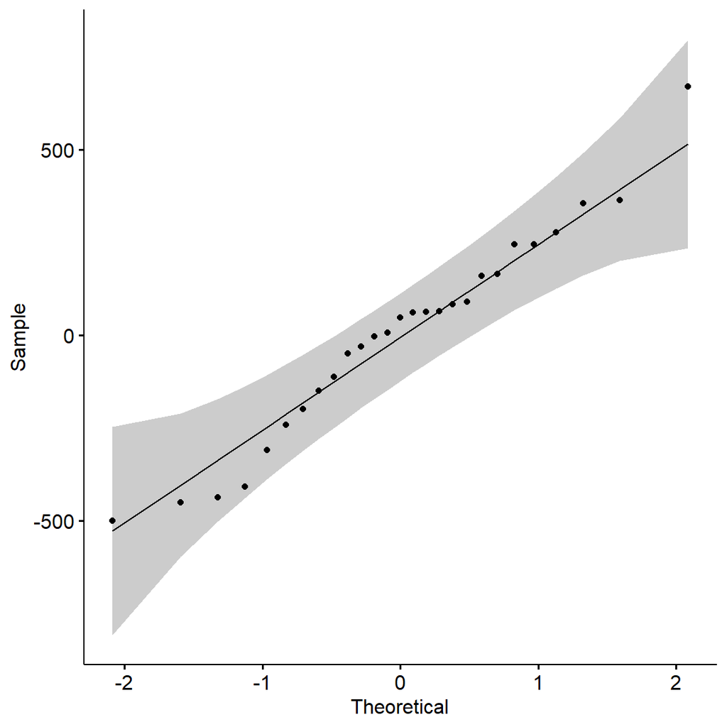

```r
ggqqplot(residuals(res))
```

Homogeneity of residuals:

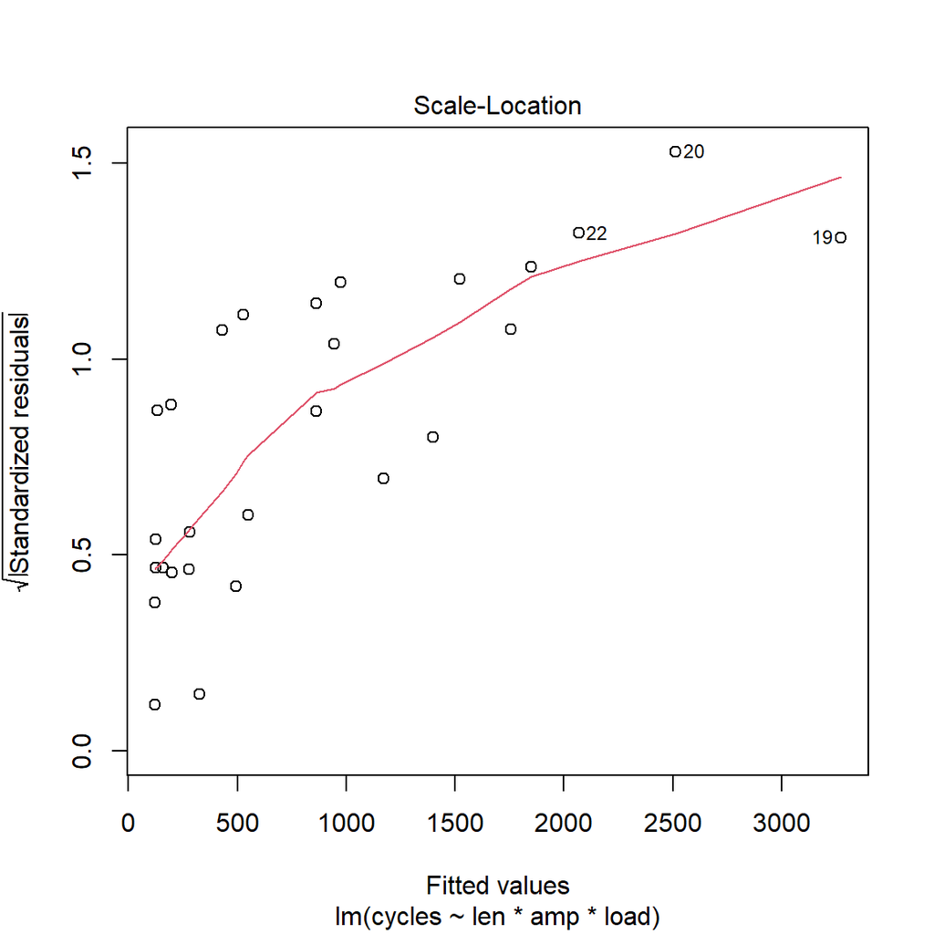

```r
plot(res, 3)
```

Histogram:

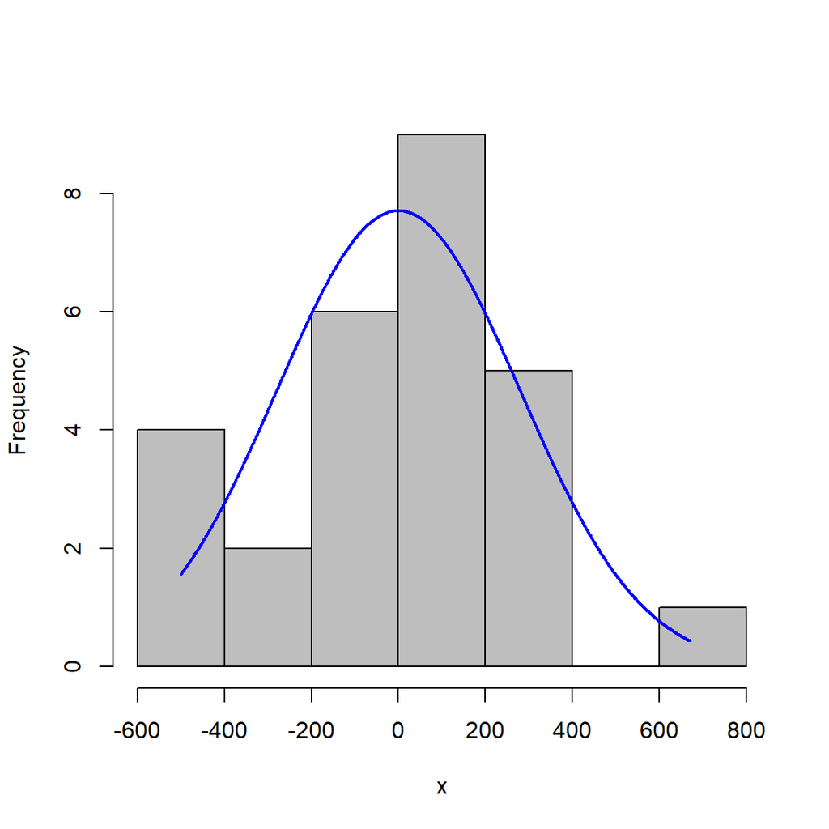

```r
plotNormalHistogram(residuals(res))
```

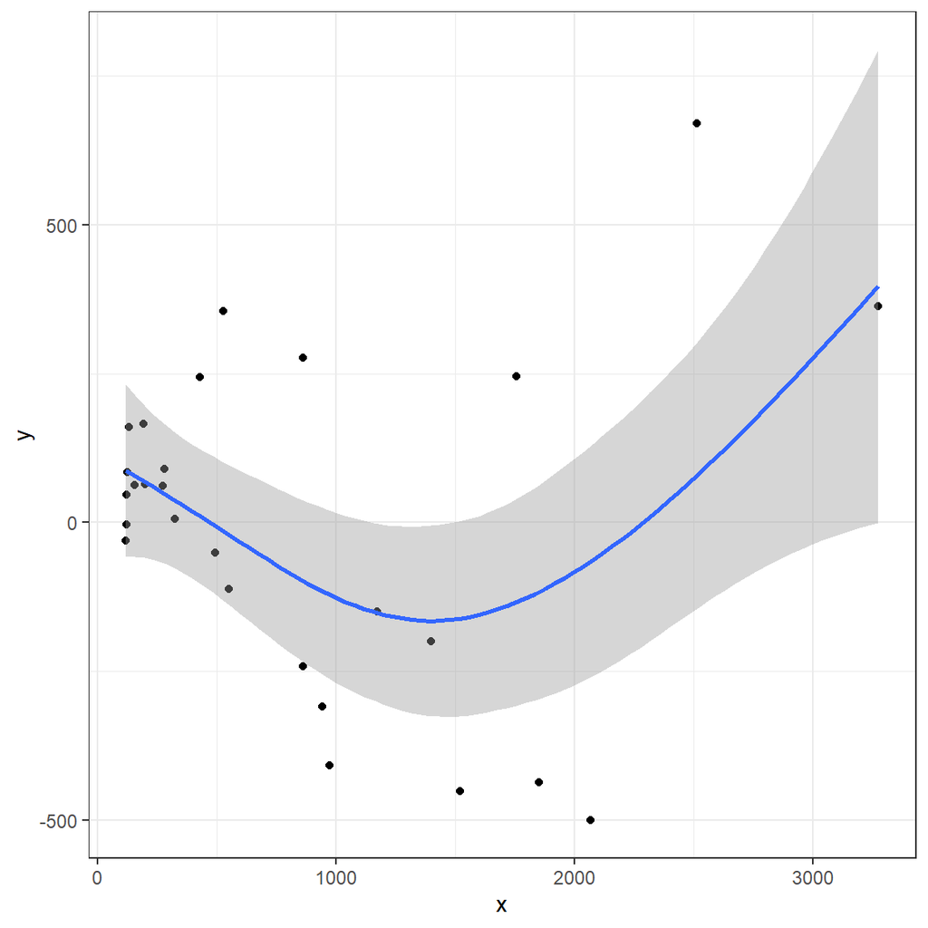

```r
tibble(
    x = fitted(res),
    y = resid(res)
) %>%
    ggplot(aes(x = x, y = y)) +
    geom_point() +
    geom_smooth(method = "gam")
```

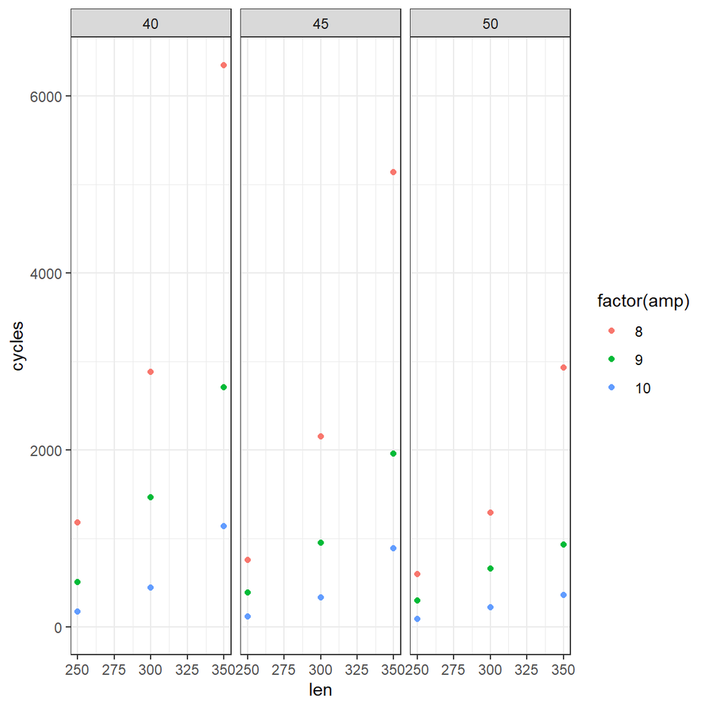

```r
ggplot(Wool)+
  geom_point(aes(x = len, y = cycles, colour = factor(amp)), position = 'stack')+
  geom_point(aes(x = len,  y = cycles, colour = factor(amp)), position = 'stack') +
  geom_point(aes(x = len, y = cycles, colour = factor(amp)), position = 'stack') +
  facet_wrap(~load)
```

```r
skewness(Wool$cycles)
```

```
[1] 1.785385
```

‘cycles’ variable is right-skewed. We should apply log transformation

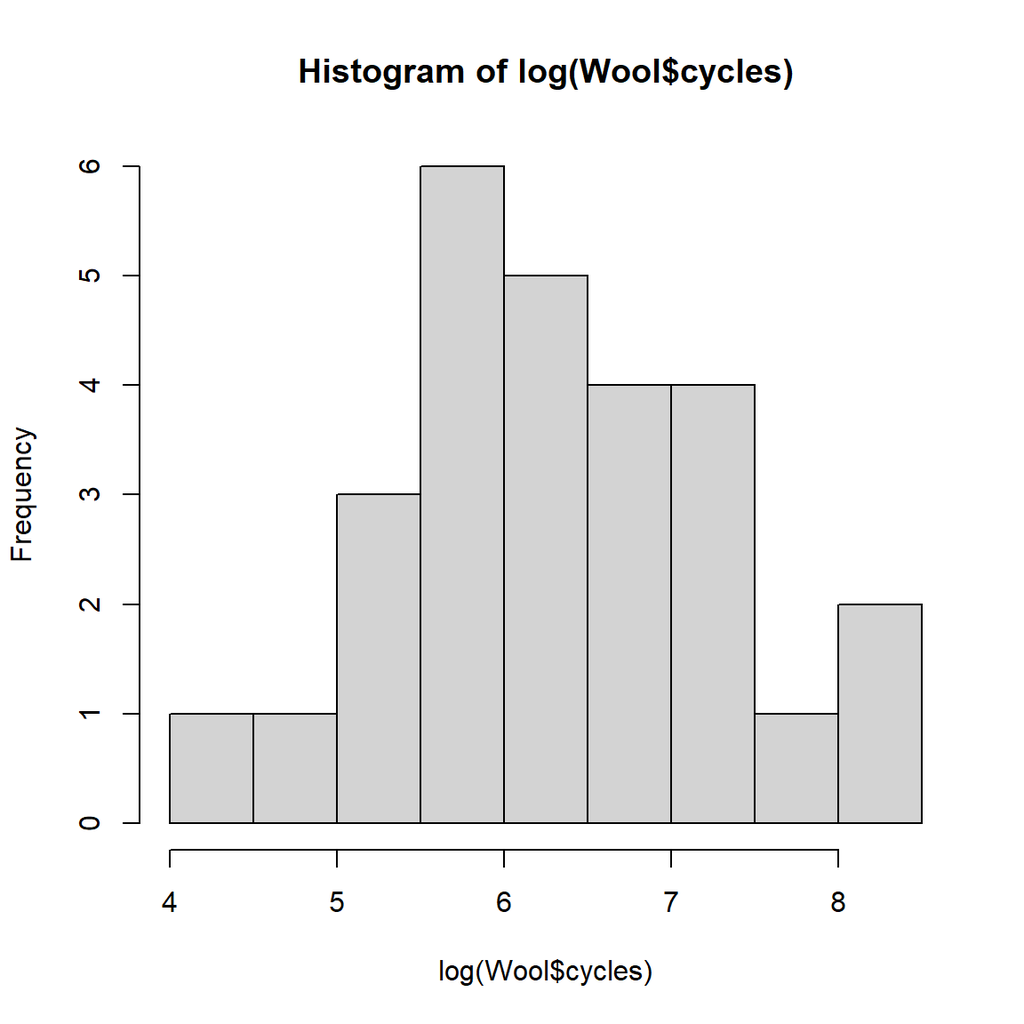

```r
hist(log(Wool$cycles))
```

```r
skewness(log(Wool$cycles))
```

```
[1] 0.09570965
```

```r
model <- lm(log(cycles) ~ len * (amp + load), data = Wool)
summary(model)
```

```
Call:
lm(formula = log(cycles) ~ len * (amp + load), data = Wool)

Residuals:
     Min       1Q   Median       3Q      Max
-0.36750 -0.11250 -0.00293  0.11202  0.28643

Coefficients:
              Estimate Std. Error t value Pr(>|t|)
(Intercept)  4.7923895  4.1246237   1.162   0.2583
len          0.0358458  0.0136232   2.631   0.0156 *
amp         -0.4014177  0.3233963  -1.241   0.2282
load         0.0035736  0.0646793   0.055   0.9565
len:amp     -0.0007648  0.0010681  -0.716   0.4819
len:load    -0.0002737  0.0002136  -1.281   0.2142
---
Signif. codes:  0 '***' 0.001 '**' 0.01 '*' 0.05 '.' 0.1 ' ' 1

Residual standard error: 0.185 on 21 degrees of freedom
Multiple R-squared:  0.969, Adjusted R-squared:  0.9616
F-statistic: 131.4 on 5 and 21 DF,  p-value: 4.156e-15
```

```r
model_2 <- lm(log(cycles) ~ amp * (len + load), data = Wool)
summary(model_2)
```

```
Call:
lm(formula = log(cycles) ~ amp * (len + load), data = Wool)

Residuals:
     Min       1Q   Median       3Q      Max
-0.43592 -0.14051  0.00371  0.12496  0.28643

Coefficients:
              Estimate Std. Error t value Pr(>|t|)
(Intercept)  6.7839668  5.4174530   1.252   0.2242
amp         -0.2122165  0.5994773  -0.354   0.7269
len          0.0235311  0.0099885   2.356   0.0283 *
load        -0.0406837  0.0998846  -0.407   0.6879
amp:len     -0.0007648  0.0011053  -0.692   0.4965
amp:load    -0.0042045  0.0110529  -0.380   0.7075
---
Signif. codes:  0 '***' 0.001 '**' 0.01 '*' 0.05 '.' 0.1 ' ' 1

Residual standard error: 0.1914 on 21 degrees of freedom
Multiple R-squared:  0.9668,    Adjusted R-squared:  0.9589
F-statistic: 122.4 on 5 and 21 DF,  p-value: 8.493e-15
```

No significant interactions. We can remove them from the model

```r
model1 <- lm(log(cycles) ~ load + len + amp, data = Wool)
summary(model1)
```

```
Call:
lm(formula = log(cycles) ~ load + len + amp, data = Wool)

Residuals:
     Min       1Q   Median       3Q      Max
-0.43592 -0.11250  0.00802  0.11635  0.26790

Coefficients:
             Estimate Std. Error t value Pr(>|t|)
(Intercept) 10.551813   0.616683  17.111 1.41e-14 ***
load        -0.078524   0.008750  -8.974 5.66e-09 ***
len          0.016648   0.000875  19.025 1.43e-15 ***
amp         -0.630866   0.043752 -14.419 5.22e-13 ***
---
Signif. codes:  0 '***' 0.001 '**' 0.01 '*' 0.05 '.' 0.1 ' ' 1

Residual standard error: 0.1856 on 23 degrees of freedom
Multiple R-squared:  0.9658,    Adjusted R-squared:  0.9614
F-statistic: 216.8 on 3 and 23 DF,  p-value: < 2.2e-16
```

```r
etasq(model1, anova = TRUE, partial = TRUE, type = 2)
```

```
Anova Table (Type II tests)

Response: log(cycles)
          Partial eta^2  Sum Sq Df F value    Pr(>F)
load            0.77784  2.7747  1  80.528 5.660e-09 ***
len             0.94025 12.4715  1 361.950 1.433e-15 ***
amp             0.90039  7.1639  1 207.910 5.218e-13 ***
Residuals                0.7925 23
---
Signif. codes:  0 '***' 0.001 '**' 0.01 '*' 0.05 '.' 0.1 ' ' 1
```

Significant main effects of load, len, amp.

Post-hoc tests:

Main effects of len, amp, load:

```r
Wool2 <- Wool
Wool2$len <- as.factor(Wool2$len)
Wool2$load <- as.factor(Wool2$load)
Wool2$amp <- as.factor(Wool2$amp)

model2 <- lm(log(cycles) ~ load + len + amp, data = Wool2)
```

```r
pairs(emmeans(model2, "load"), reverse = TRUE) %>%
  confint
```

```
 contrast estimate     SE df lower.CL upper.CL
 45 - 40    -0.325 0.0893 20   -0.551  -0.0994
 50 - 40    -0.785 0.0893 20   -1.011  -0.5594
 50 - 45    -0.460 0.0893 20   -0.686  -0.2341

Results are averaged over the levels of: len, amp
Results are given on the log (not the response) scale.
Confidence level used: 0.95
Conf-level adjustment: tukey method for comparing a family of 3 estimates
```

```r
pairs(emmeans(model2, "len"), reverse = TRUE)%>%
  confint
```

```
 contrast  estimate     SE df lower.CL upper.CL
 300 - 250    0.918 0.0893 20    0.692    1.144
 350 - 250    1.665 0.0893 20    1.439    1.891
 350 - 300    0.746 0.0893 20    0.521    0.972

Results are averaged over the levels of: load, amp
Results are given on the log (not the response) scale.
Confidence level used: 0.95
Conf-level adjustment: tukey method for comparing a family of 3 estimates
```

```r
pairs(emmeans(model2, "amp"), reverse = TRUE)%>%
  confint
```

```
 contrast estimate     SE df lower.CL upper.CL
 9 - 8      -0.655 0.0893 20   -0.881   -0.429
 10 - 8     -1.262 0.0893 20   -1.488   -1.036
 10 - 9     -0.607 0.0893 20   -0.832   -0.381

Results are averaged over the levels of: load, len
Results are given on the log (not the response) scale.
Confidence level used: 0.95
Conf-level adjustment: tukey method for comparing a family of 3 estimates
```

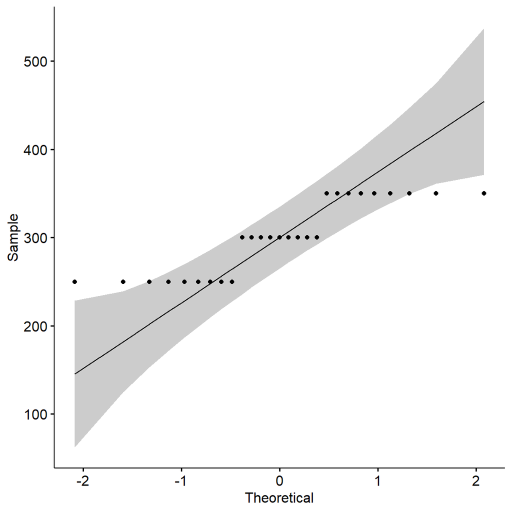

```r
ggqqplot(Wool$len)
```

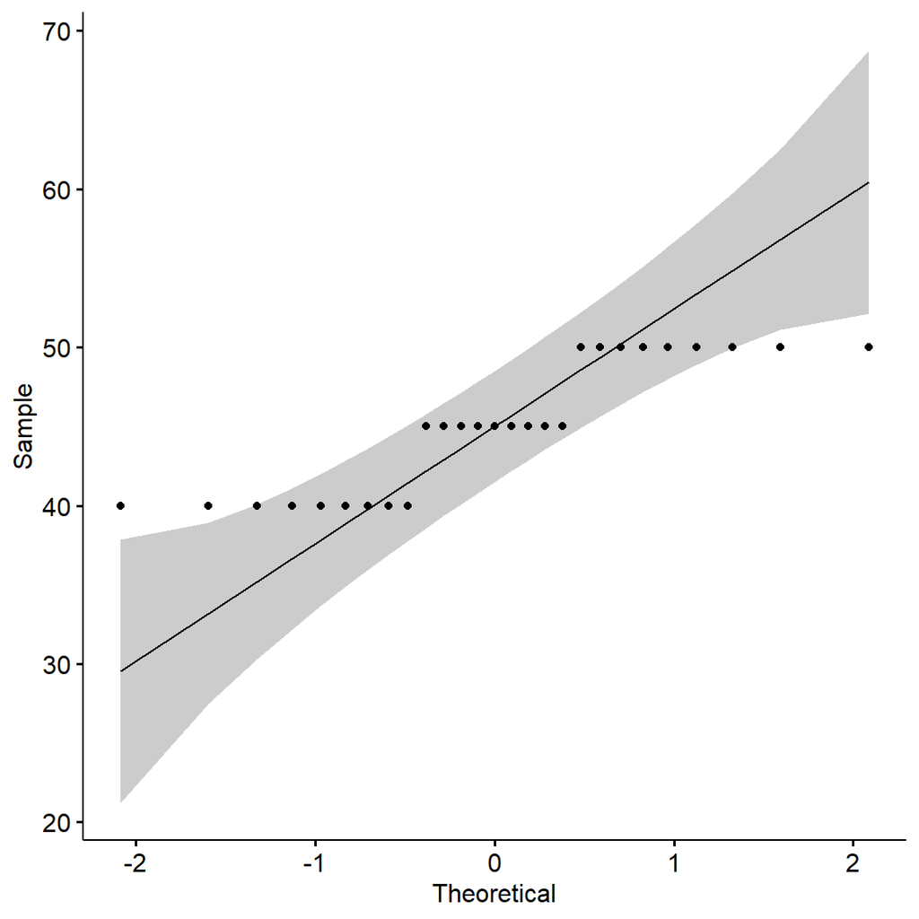

```r
ggqqplot(Wool$load)
```

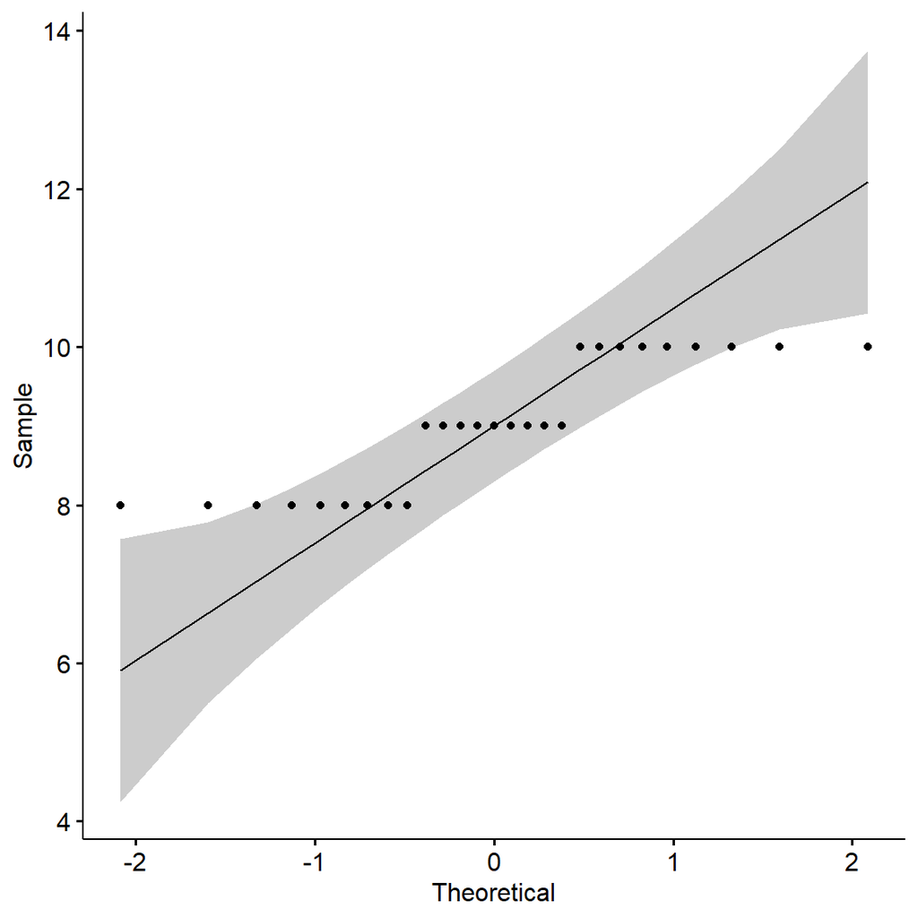

```r
ggqqplot(Wool$amp)
```

```r
model1 %>%
  confint()
```

```
                  2.5 %      97.5 %
(Intercept)  9.27610607 11.82751939
load        -0.09662556 -0.06042224
len          0.01483752  0.01845785
amp         -0.72137430 -0.54035774
```

Report:

To study which factors were associated with cycles failure, a linear regression model was fitted. The response variable (cycles) was a continuous indicator of number of cycles until failure. The factors were len (length of specimen (250, 300, 350 mm)), amp (amplitude of loading cycle (8, 9, 10 min)) and load (40, 45, 50g). The experiment explored combination of 3 factors at three levels, giving 27 unique combinations. The model did not include interaction effects, as they were not significant. The response variable (cycles) was right-skewed, so log transformation has been applied. Multiple R-squared: 0.9658, which indicates that the model explains a great amount of cycles variation. Obtained regression coefficients were:

- load: -0.078524 with 95% CI = [-0.09662556, -0.06042224], p-value < 0.01
- len: 0.016648 with 95% CI = [0.01483752, 0.01845785], p-value < 0.01
- amp: -0.630866 with 95% CI = [-0.72137430, -0.54035774], p-value < 0.01

The following regression model was acquired.

$$log(\hat{y_i}) = 10.551813 - 0.078524*x1_i + 0.016648*x2_i -0.630866*x3_i
\\\hat{y_i} = e^{10.551813}e^{-0.078524*x1_i}e^ {0.016648*x2_i} e^{-0.630866*x3_i}$$

($x1$ - load, $x2$ - len, $x3$ - amp)

## 5. (2 points)

Use `TitanicSurvival` dataset from `carData` package (see `?TitanicSurvival`). Use it to find out who was most likely to survive the *Titanic* catastrophe. The response is the dichotomous `survived` variable.

For convenience, the dataset is assigned to `Titanic` variable.

As always, report and describe your results properly. Try to visualize them if it may facilitate understanding.

```r
data(TitanicSurvival)
(Titanic <- tibble(TitanicSurvival))
```

```
# A tibble: 1,309 x 4
   survived sex       age passengerClass
   <fct>    <fct>   <dbl> <fct>
 1 yes      female 29     1st
 2 yes      male    0.917 1st
 3 no       female  2     1st
 4 no       male   30     1st
 5 no       female 25     1st
 6 yes      male   48     1st
 7 yes      female 63     1st
 8 no       male   39     1st
 9 yes      female 53     1st
10 no       male   71     1st
# ... with 1,299 more rows
```

```r
Titanic <- Titanic[complete.cases(Titanic),]
Titanic <- Titanic %>% mutate(
    survivedYes = ifelse(survived == "yes", 1, 0),
    sexFemale = ifelse(sex == "female", 1, 0),
    class = as.numeric(factor(passengerClass, levels = c("1st","2nd","3rd"))))
```

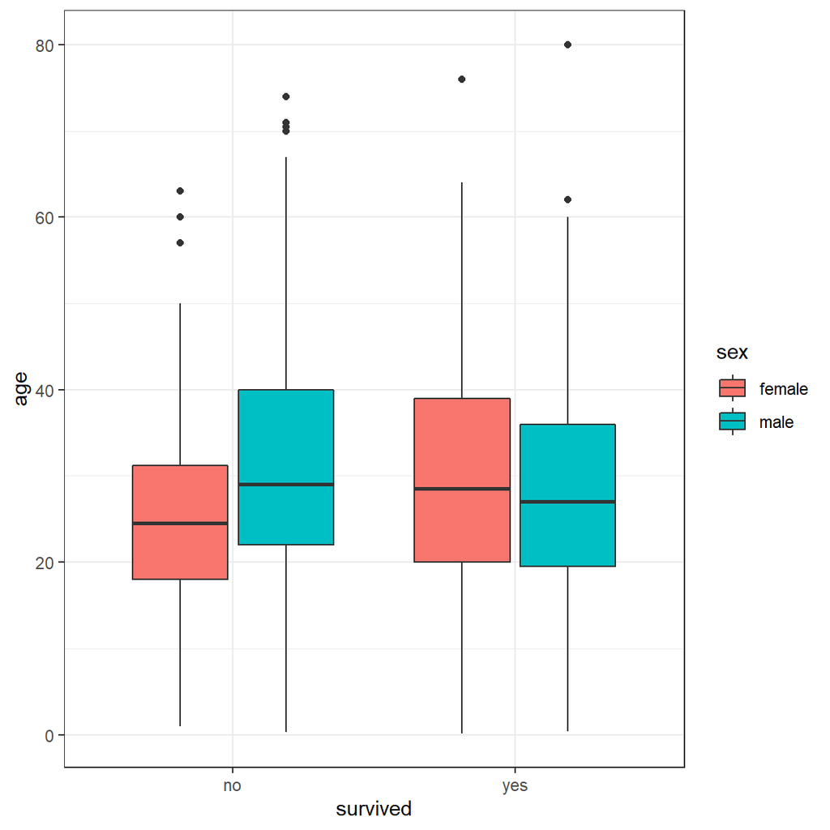

```r
ggplot(Titanic, aes(x=survived, y=age, fill=sex)) +
    geom_boxplot()
```

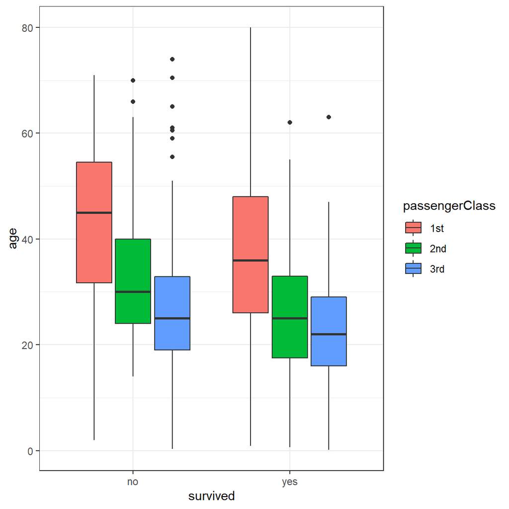

```r
ggplot(Titanic, aes(x=survived, y=age, fill=passengerClass)) +
    geom_boxplot()
```

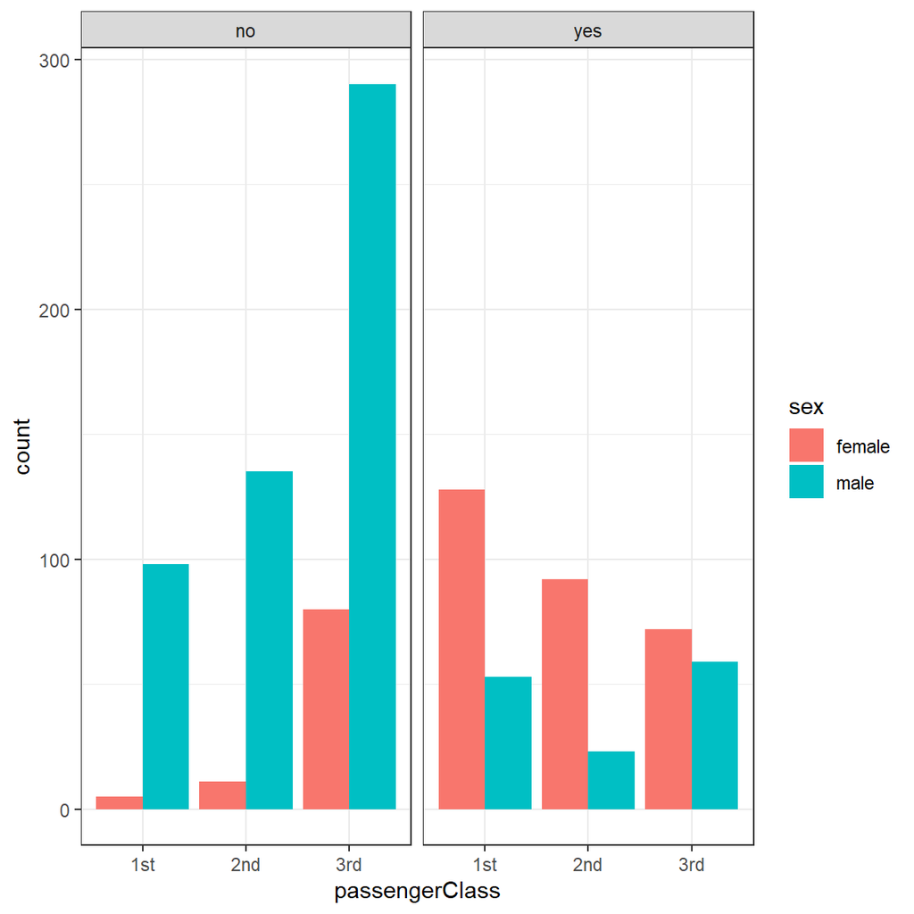

```r
ggplot(Titanic)+
  geom_bar(aes(x = passengerClass, fill = sex), position = 'dodge')+
  geom_bar(aes(x = passengerClass, fill = sex), position = 'dodge') +
  facet_wrap(~survived)
```